# Chapter 14 HMSC final model analysis

This chapter loads the fitted `model_final` posterior from ERDA, runs variance partitioning and association analyses, and writes `data/publication_hmsc.Rdata` for chapter 15 (publication figures).

```r
library(tidyverse)
library(Hmsc)
library(ape)
library(distillR)
library(ggrepel)
library(forcats)
```

## 14.1 Load data

**Note:** Load the main data file containing sample metadata, genome counts, genome metadata, phylogenetic tree, and other required objects. Also load GIFT color scheme for functional annotation visualization.

```r
source("R/chapter_deps.R")
load("data/data.Rdata")
ensure_gift_db()

gift_colors <- read_tsv("data/gift_colors.tsv") %>%
  mutate(legend=str_c(Code_function," - ",Function))
```

## 14.2 Set parameters

**Note:** Define HMSC model parameters including number of MCMC samples, thinning interval, transient (burn-in) period, and posterior support thresholds for determining positive/negative associations.

```r
#Parameters
nSamples=250
thin=1000
transient=nSamples * thin
support_threshold=0.9
negsupport_threshold=1-support_threshold
```

## 14.3 Helper functions

**Note:** Define reusable helper functions to extract beta estimates, support values, and credible intervals from HMSC models. These functions eliminate code duplication and ensure consistent extraction patterns across all analyses.

```r
# Safe correlation function that checks dimensions
safe_cor <- function(x, y, ...) {
  if (length(x) != length(y)) {
    warning(paste("Vectors have incompatible dimensions:", length(x), "vs", length(y), ". Returning NA."))
    return(NA)
  }
  if (length(x) == 0) {
    return(NA)
  }
  tryCatch({
    cor(x, y, ...)
  }, error = function(e) {
    warning(paste("Error computing correlation:", e$message))
    return(NA)
  })
}

# Extract beta mean estimate for a specific covariate
get_beta_estimate <- function(fit_model_18, model_obj, covariate_name) {
  getPostEstimate(hM = fit_model_18, parName = "Beta")$mean %>%
    as.data.frame() %>%
    mutate(variable = model_obj$covNames) %>%
    filter(variable == covariate_name) %>%
    pivot_longer(!variable, names_to = "genome", values_to = "mean") %>%
    dplyr::select(genome, mean)
}

# Extract beta support values for a specific covariate
get_beta_support <- function(fit_model_18, model_obj, covariate_name) {
  getPostEstimate(hM = fit_model_18, parName = "Beta")$support %>%
    as.data.frame() %>%
    mutate(variable = model_obj$covNames) %>%
    filter(variable == covariate_name) %>%
    pivot_longer(!variable, names_to = "genome", values_to = "support") %>%
    dplyr::select(genome, support)
}

# Extract beta credible intervals for a specific covariate
get_beta_ci <- function(fit_model_18, model_obj, covariate_name, quantiles = c(0.1, 0.9)) {
  beta_q <- getPostEstimate(hM = fit_model_18, parName = "Beta", q = quantiles)$q
  idx_cov <- which(model_obj$covNames == covariate_name)
  n_genomes <- length(model_obj$spNames)

  purrr::map_dfr(1:n_genomes, ~ {
    tibble(
      genome = model_obj$spNames[.x],
      q10    = beta_q[1, idx_cov, .x],
      q90    = beta_q[2, idx_cov, .x]
    )
  })
}

# Combine beta estimate, support, and credible intervals with metadata
get_beta_complete <- function(fit_model_18, model_obj, covariate_name, quantiles = c(0.1, 0.9)) {
  estimate <- get_beta_estimate(fit_model_18, model_obj, covariate_name)
  ci <- get_beta_ci(fit_model_18, model_obj, covariate_name, quantiles)

  ci %>%
    right_join(estimate, by = "genome") %>%
    left_join(genome_metadata, by = "genome")
}

# Calculate functional differences between positive and negative associations
calculate_functional_differences <- function(elements_response, variable_name) {
  var_sym <- rlang::sym(variable_name)

  elements_response %>%
    filter(!!var_sym != "Neutral") %>%
    mutate(!!var_sym := droplevels(!!var_sym)) %>%
    group_by(GIFT) %>%
    summarise(
      n_pos   = sum(!!var_sym == "Positive"),
      n_neg   = sum(!!var_sym == "Negative"),
      mean_pos = mean(value[!!var_sym == "Positive"], na.rm = TRUE),
      mean_neg = mean(value[!!var_sym == "Negative"], na.rm = TRUE),
      diff     = mean_pos - mean_neg,
      p        = if (n_pos > 1 && n_neg > 1 &&
                     stats::sd(value[!!var_sym == "Positive"], na.rm = TRUE) > 0 &&
                     stats::sd(value[!!var_sym == "Negative"], na.rm = TRUE) > 0) {
                  stats::t.test(value ~ !!var_sym, var.equal = FALSE)$p.value
                } else NA_real_,
      .groups = "drop"
    ) %>%
    mutate(p_adj = p.adjust(p, method = "BH")) %>%
    arrange(p_adj)
}

# Create volcano plot for functional differences
create_volcano_plot <- function(functional_differences, variable_label, gift_colors) {
  fc_threshold <- 0.2
  fdr_threshold <- 0.05

  plot_data <- functional_differences %>%
    mutate(func = substr(GIFT, 1, 3)) %>%
    mutate(
      p_adj_plot = ifelse(is.na(p_adj) | p_adj == 0, .Machine$double.xmin, p_adj),
      neglog10_fdr = -log10(p_adj_plot),
      hit = !is.na(p_adj) & p_adj < fdr_threshold & abs(diff) >= fc_threshold
    ) %>%
    mutate(func = ifelse(hit, func, "NS")) %>%
    filter(neglog10_fdr < 20)

  # Build color palette
  func_levels <- sort(unique(plot_data$func))
  palette_df <- tibble(func = func_levels) %>%
    left_join(
      gift_colors %>% select(func = Code_function, Color),
      by = "func"
    ) %>%
    mutate(
      Color = case_when(
        func == "NS" & is.na(Color) ~ "grey70",
        is.na(Color)                ~ "#999999",
        TRUE                        ~ Color
      )
    )

  color_values <- setNames(palette_df$Color, palette_df$func)

  plot_data %>%
    ggplot(aes(x = diff, y = neglog10_fdr, color = func)) +
    geom_point(alpha = 0.8, size = 2) +
    geom_vline(xintercept = c(-fc_threshold, fc_threshold), linetype = "dashed") +
    geom_hline(yintercept = -log10(fdr_threshold), linetype = "dashed") +
    ylim(0, 15) +
    xlim(-0.6, 0.6) +
    ggrepel::geom_text_repel(
      data = subset(plot_data, hit),
      aes(label = GIFT),
      size = 3, max.overlaps = 20, box.padding = 0.3, min.segment.length = 0
    ) +
    scale_color_manual(values = color_values) +
    labs(
      x = "Mean difference (Positive − Negative)",
      y = expression(-log[10]("FDR (BH)")),
      color = "Group",
      subtitle = paste0("Thresholds: |diff| ≥ ", fc_threshold, ", FDR < ", fdr_threshold)
    ) +
    theme_minimal(base_size = 12)
}

# Aggregate beta coefficients by taxonomic level
aggregate_by_taxonomy <- function(ci_data, tax_level = "phylum") {
  tax_sym <- rlang::sym(tax_level)

  ci_data %>%
    group_by(!!tax_sym) %>%
    summarise(
      mean_beta = mean(mean, na.rm = TRUE),
      q10 = stats::quantile(mean, 0.1, na.rm = TRUE),
      q90 = stats::quantile(mean, 0.9, na.rm = TRUE),
      .groups = "drop"
    )
}

# Aggregate beta coefficients by functional group
aggregate_by_function <- function(ci_data, elements_response, gift_colors, n_top = 15, min_genomes = 3) {
  # Extract genome effects
  genome_effects <- ci_data %>%
    dplyr::select(genome, mean, q10, q90)

  # Map genomes to functional groups
  genome_func <- elements_response %>%
    dplyr::filter(value > 0) %>%
    dplyr::mutate(func = substr(GIFT, 1, 3)) %>%
    dplyr::distinct(genome, func)

  # Summarise by functional group
  func_summary <- genome_func %>%
    dplyr::left_join(genome_effects, by = "genome") %>%
    dplyr::group_by(func) %>%
    dplyr::summarise(
      n_genomes = sum(!is.na(mean)),
      mean_beta = mean(mean, na.rm = TRUE),
      q10_fun   = stats::quantile(mean, 0.10, na.rm = TRUE),
      q90_fun   = stats::quantile(mean, 0.90, na.rm = TRUE),
      .groups   = "drop"
    ) %>%
    dplyr::filter(n_genomes >= min_genomes)

  # Get top positive and negative
  func_top <- dplyr::bind_rows(
    func_summary %>%
      dplyr::slice_max(order_by = mean_beta, n = n_top, with_ties = FALSE),
    func_summary %>%
      dplyr::slice_min(order_by = mean_beta, n = n_top, with_ties = FALSE)
  ) %>%
    dplyr::distinct(func, .keep_all = TRUE)

  # Add labels and colors
  func_top %>%
    dplyr::left_join(
      gift_colors %>%
        dplyr::transmute(
          func        = Code_function,
          func_label  = legend,
          color       = Color
        ),
      by = "func"
    ) %>%
    dplyr::mutate(
      func_label = ifelse(is.na(func_label), func, func_label)
    )
}

# Create forest plot for beta coefficients
create_forest_plot <- function(data, x_var = "mean", y_var = NULL, xmin_var = "q10", xmax_var = "q90",
                               color_var = NULL, color_values = NULL, x_lab = "β coefficient",
                               y_lab = NULL, show_legend = TRUE, base_size = 10, errorbar_width = 0,
                               facet_var = NULL) {
  # Determine y variable if not provided
  if (is.null(y_var)) {
    y_var <- if ("genome" %in% names(data)) "genome" else
             if ("phylum" %in% names(data)) "phylum" else
             if ("func_label" %in% names(data)) "func_label" else
             names(data)[1]
  }

  # Reorder y variable by x variable
  y_sym <- rlang::sym(y_var)
  x_sym <- rlang::sym(x_var)
  data <- data %>%
    mutate(!!y_sym := forcats::fct_reorder(!!y_sym, !!x_sym))

  # Build plot
  p <- ggplot(data, aes_string(x = x_var, y = y_var, xmin = xmin_var, xmax = xmax_var))

  # Add color if specified
  if (!is.null(color_var) && color_var %in% names(data)) {
    p <- p + aes_string(colour = color_var)
  }

  p <- p +
    geom_point(size = 2) +
    geom_errorbar(width = errorbar_width) +
    geom_vline(xintercept = 0) +
    theme_minimal(base_size = base_size) +
    labs(x = x_lab, y = ifelse(is.null(y_lab), y_var, y_lab))

  # Add color scale if specified
  if (!is.null(color_var) && !is.null(color_values)) {
    p <- p + scale_color_manual(values = color_values)
  }

  # Add faceting if specified
  if (!is.null(facet_var) && facet_var %in% names(data)) {
    p <- p + facet_grid(paste0(facet_var, " ~ ."), scales = "free_y", space = "free_y")
  }

  # Legend position
  if (!show_legend) {
    p <- p + theme(legend.position = "none")
  } else {
    p <- p + theme(legend.position = "right")
  }

  return(p)
}
```

## 14.4 Load HMSC model

**Note:** Load the unfitted HMSC model object and download the fitted model from HPC. Import posterior samples from the HPC output and combine them into a fitted model object for downstream analysis.

```r
#Load unfitted
load(file = "hmsc/model_final")

#Load fitted (as a temporary file)
tmp <- tempfile(fileext = ".rds")
options(timeout = max(600, getOption("timeout")))
download.file("https://sid.erda.dk/share_redirect/Gh0WbM42c4/Hmsc_model_final.rds", tmp, mode = "wb")
hpc_fit <- readRDS(tmp)
unlink(tmp)

importFromHPC <- hpc_fit$list
n_sp_fit <- ncol(importFromHPC[[1]][[1]]$Beta)
n_tasmania_samples <- sum(sample_metadata$island == "Tasmania")
if (length(m$spNames) != n_sp_fit) {
  stop(
    "model_final: unfitted model (", length(m$spNames), " genomes) does not match fitted posterior (",
    n_sp_fit, " genomes). Use the canonical hmsc/model_final built from data/model_final_genomes.tsv.",
    call. = FALSE
  )
}
if (nrow(m$XData) != n_tasmania_samples) {
  stop(
    "model_final: unfitted model has ", nrow(m$XData),
    " samples but Tasmania analysis expects ", n_tasmania_samples, ".", call. = FALSE
  )
}

postList <- importFromHPC[1:4]
fit_model_18 <- importPosteriorFromHPC(m, postList, nSamples, thin, transient)
```

## 14.5 Variance partitioning

**Note:** Compute variance partitioning to quantify the proportion of variance explained by each predictor variable and random effect. Calculate predicted values and evaluate model fit using R². Display summary statistics of variance partitioning across all genomes.

```r
# Compute variance partitioning
varpart=computeVariancePartitioning(fit_model_18)

varpart$vals %>%
   as.data.frame() %>%
   rownames_to_column(var="variable") %>%
   pivot_longer(!variable, names_to = "genome", values_to = "value") %>%
   mutate(variable=factor(variable)) %>%
   group_by(variable) %>%
   summarise(mean=mean(value)*100,sd=sd(value)*100) %>%
   tt()
```

| variable | mean | sd |
| --- | --- | --- |
| devil | 7.3595616 | 3.7212069 |
| devil:temperature | 7.1495449 | 3.7965784 |
| diversity | 0.3691411 | 0.5011564 |
| logseqdepth | 2.2411137 | 2.1351820 |
| Random: animal | 61.1535423 | 15.0431620 |
| Random: site | 20.2588552 | 12.7792359 |
| temperature | 1.4682412 | 1.2921420 |

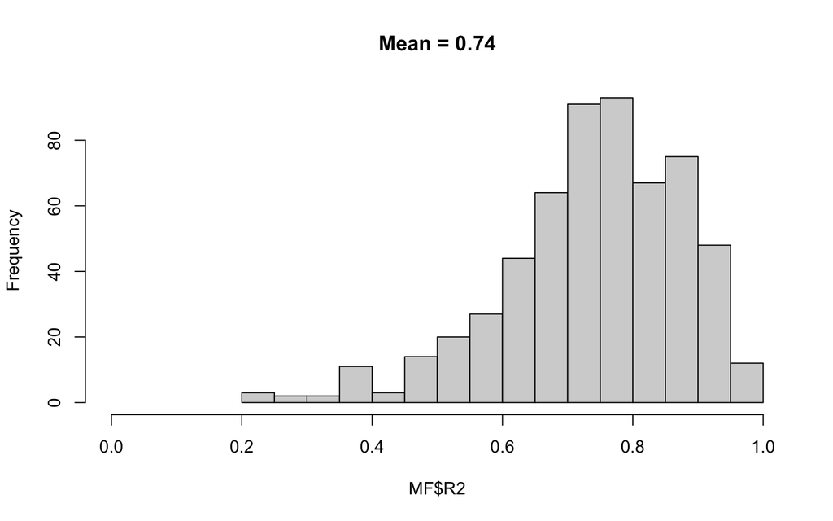

```r
preds = computePredictedValues(fit_model_18)
MF = evaluateModelFit(hM=fit_model_18, predY=preds)
hist(MF$R2, xlim = c(0,1), main=paste0("Mean = ", round(mean(MF$R2),2)))
```

## 14.6 Variance partitioning tree plot

**Note:** Visualize variance partitioning results on a phylogenetic tree. Build a phylogeny matching the genomes in variance partitioning results, add phylum annotations as a heatmap, and display variance components as stacked bars for each genome, showing the relative contribution of each predictor variable.

```r
# 1) Build the phylogeny in the same species set/order as varpart
vp_tree_phylo <- genome_tree %>%
  keep.tip(tip = colnames(varpart$vals)) %>%
  force.ultrametric(method = "extend")

vp_tree <- ggtree(vp_tree_phylo, size = 0.3)

# 2) Phylum annotation in tree tip order
phylums_vp <- genome_metadata %>%
  filter(genome %in% vp_tree$data$label) %>%
  arrange(match(genome, vp_tree$data$label)) %>%
  mutate(phylum = factor(phylum, levels = unique(phylum))) %>%
  column_to_rownames("genome") %>%
  select(phylum)

vp_tree <- gheatmap(
  vp_tree,
  phylums_vp,
  offset    = -0.2,
  width     = 0.1,
  colnames  = FALSE
) +
  scale_fill_manual(values = phylum_colors) +
  labs(fill = "Phylum")

# start a new fill scale for the variance bars
vp_tree <- vp_tree + new_scale_fill()

# 3) Long variance-partitioning table
varpart_long <- varpart$vals %>%
  as.data.frame() %>%
  rownames_to_column("variable") %>%
  pivot_longer(
    cols      = -variable,
    names_to  = "label",   # must be 'label' to match tree tip labels
    values_to = "value"
  ) %>%
  mutate(
    # reorder predictors in a sensible way for the legend
    variable = factor(
      variable,
      levels = rev(c(
        "devil", "temperature", "diversity",
        "logseqdepth", "devil:temperature",
        "Random: animal", "Random: site"
      ))
    )
  )

# 4) Add stacked bars with geom_fruit
vp_tree +
  geom_fruit(
    data   = varpart_long,
    geom   = geom_bar,
    mapping = aes(
      x    = value,
      y    = label,
      fill = variable
    ),
    stat        = "identity",
    orientation = "y",
    pwidth      = 2,
    offset      = 0.05
  ) +
  labs(fill = "Variable")
```

[output not shown]

## 14.7 Phylogenetic signal

**Note:** Assess phylogenetic signal (Rho) in the HMSC model by converting posterior samples to coda format. Extract Rho values from the posterior distribution and compute credible intervals (5th, 50th, 95th percentiles) to quantify the strength of phylogenetic signal in species responses.

```r
# Convert to coda object to inspect Rho (phylogenetic signal)
mpost <- convertToCodaObject(fit_model_18)

# Overall Rho posterior (phylogenetic signal on the species random effect)
rho_vec <- unlist(mpost$Rho)

# 90% credible interval and median
rho_summary <- quantile(rho_vec, probs = c(0.05, 0.5, 0.95))
rho_summary
```

```
##   5%  50%  95%
## 0.98 0.99 0.99
```

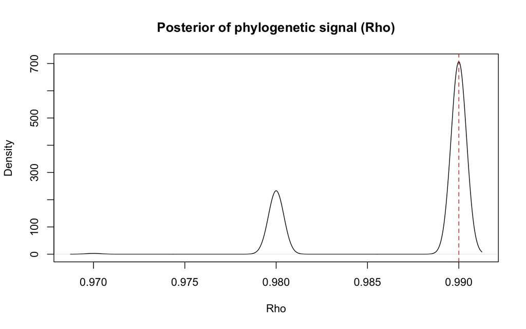

```r
# Optional: density plot for the appendix
plot(density(rho_vec),
     main = "Posterior of phylogenetic signal (Rho)",
     xlab = "Rho")
abline(v = rho_summary[2], col = "red", lty = 2)
```

## 14.8 Posterior estimates visualization

**Note:** Extract posterior support values for all predictor variables and classify each genome-variable combination as Positive, Negative, or Neutral based on support thresholds. Create a phylogenetic tree visualization with phylum annotations and a heatmap showing posterior trends for all predictor variables across genomes.

```r
hmsc_tree <- genome_tree %>%
  keep.tip(., tip = m$spNames)

post_estimates <- getPostEstimate(hM = fit_model_18, parName = "Beta")$support %>%
  as.data.frame() %>%
  mutate(variable = m$covNames) %>%
  pivot_longer(!variable, names_to = "genome", values_to = "value") %>%
  mutate(trend = case_when(
    value >= support_threshold ~ "Positive",
    value <= negsupport_threshold ~ "Negative",
    TRUE ~ "Neutral"
  ))

post_table <- post_estimates %>%
  mutate(genome = factor(genome, levels = rev(hmsc_tree$tip.label))) %>%
  select(-trend) %>%
  mutate(value = case_when(
    value >= support_threshold ~ "Positive",
    value <= negsupport_threshold ~ "Negative",
    TRUE ~ "Neutral"
  )) %>%
  mutate(value = factor(value, levels = c("Positive", "Neutral", "Negative"))) %>%
  pivot_wider(names_from = variable, values_from = value) %>%
  select(-`(Intercept)`) %>%
  column_to_rownames(var = "genome")
```

```r
postestimates_tree <- hmsc_tree %>%
  force.ultrametric(., method = "extend") %>%
  ggtree(., size = 0.3)

phylums <- genome_metadata %>%
  filter(genome %in% hmsc_tree$tip.label) %>%
  arrange(match(genome, hmsc_tree$tip.label)) %>%
  mutate(phylum = factor(phylum, levels = unique(phylum))) %>%
  column_to_rownames(var = "genome") %>%
  select(phylum)

postestimates_tree <- gheatmap(postestimates_tree, phylums, offset = -0.2, width = 0.1, colnames = FALSE) +
  scale_fill_manual(values = phylum_colors) +
  labs(fill = "Phylum")

postestimates_tree <- postestimates_tree + new_scale_fill()

postestimates_tree <- gheatmap(
  postestimates_tree, post_table,
  offset = 0, width = 0.5, colnames = TRUE,
  colnames_position = "top", colnames_angle = 90,
  colnames_offset_y = 1, hjust = 0
) +
  scale_fill_manual(values = c("#be3e2b", "#f4f4f4", "#b2b530")) +
  labs(fill = "Trend")

postestimates_tree +
  vexpand(.30, 1)
```

[output not shown]

## 14.9 Functional response data

**Note:** Create a long-format table linking genomes to their functional elements (GIFT codes) and posterior trend classifications for all predictor variables. This table enables functional-level analysis by combining genome functional profiles with their environmental associations.

```r
elements_response <- genome_gifts[rownames(post_table),colnames(genome_gifts) %in% GIFT_db$Code_bundle] %>%
  to.elements(.,GIFT_db=GIFT_db) %>%
  as.data.frame() %>%
  rownames_to_column(var="genome") %>%
  pivot_longer(!genome,names_to="GIFT", values_to="value") %>%
  left_join(post_table %>% rownames_to_column(var = "genome"), by="genome")
```

## 14.10 Export publication figure cache

**Note:** Save all HMSC objects needed by chapter 15 (publication figures) so that chapter can load results without re-importing the fitted posterior from ERDA.

```r
source("R/plot_helpers.R")

publication_hmsc_cache <- build_publication_hmsc_cache(
  fit_model = fit_model_18,
  model_obj = m,
  post_table = post_table,
  elements_response = elements_response,
  genome_metadata = genome_metadata,
  genome_tree = genome_tree,
  GIFT_db = GIFT_db,
  support_threshold = support_threshold
)

save_publication_cache(publication_hmsc_cache, publication_cache_paths()$hmsc)
message("Saved publication HMSC cache: ", publication_cache_paths()$hmsc)
```

## 14.11 Congruence of devil and temperature associations (taxonomic)

**Note:** Examine the congruence between devil and temperature associations at the taxonomic level. Create contingency tables showing how many genomes have each combination of devil and temperature responses (Positive/Negative/Neutral). Visualize patterns at the phylum level to identify taxonomic groups with consistent or contrasting responses to both variables.

```r
# Long table of trends for devil and temperature per genome
devil_temp_trends <- post_table %>%
  rownames_to_column("genome") %>%
  select(genome, devil, temperature) %>%
  left_join(genome_metadata, by = "genome")

# Overall contingency of trends
devil_temp_tab <- devil_temp_trends %>%
  count(devil, temperature) %>%
  arrange(desc(n))

devil_temp_tab %>% tt()
```

| devil | temperature | n |
| --- | --- | --- |
| Neutral | Neutral | 275 |
| Positive | Positive | 112 |
| Negative | Negative | 95 |
| Neutral | Negative | 39 |
| Neutral | Positive | 27 |
| Positive | Neutral | 18 |
| Negative | Neutral | 10 |

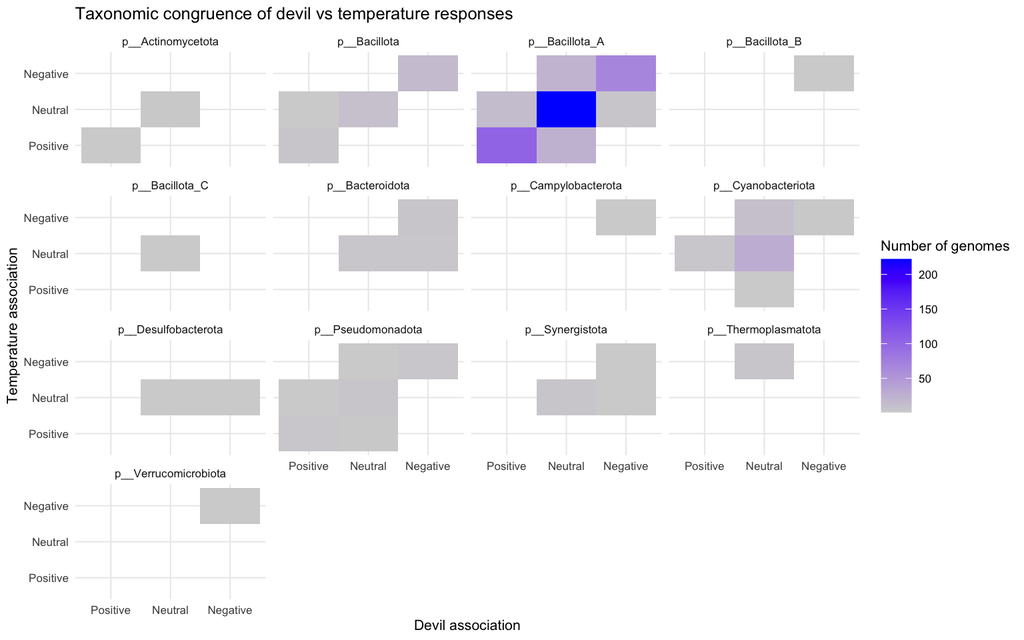

```r
# Phylum-level congruence: how many genomes in each combo
devil_temp_phylum <- devil_temp_trends %>%
  group_by(phylum, devil, temperature) %>%
  summarise(n = n(), .groups = "drop")

# Keep only non-zero combos (for cleaner plots)
devil_temp_phylum %>%
  filter(n > 0) %>%
  ggplot(aes(x = devil, y = temperature, fill = n)) +
  geom_tile() +
  facet_wrap(~ phylum) +
  scale_fill_gradient(low = "lightgrey", high = "blue") +
  labs(
    x = "Devil association",
    y = "Temperature association",
    fill = "Number of genomes",
    title = "Taxonomic congruence of devil vs temperature responses"
  ) +
  theme_minimal(base_size = 8)
```

## 14.12 Congruence of devil and temperature associations (functional)

**Note:** Examine the congruence between devil and temperature associations at the functional level. Focus on genomes with non-neutral responses to both variables. Aggregate functional element signals by functional group (GIFT Code_function) and visualize which functional groups show consistent or contrasting responses to devil and temperature.

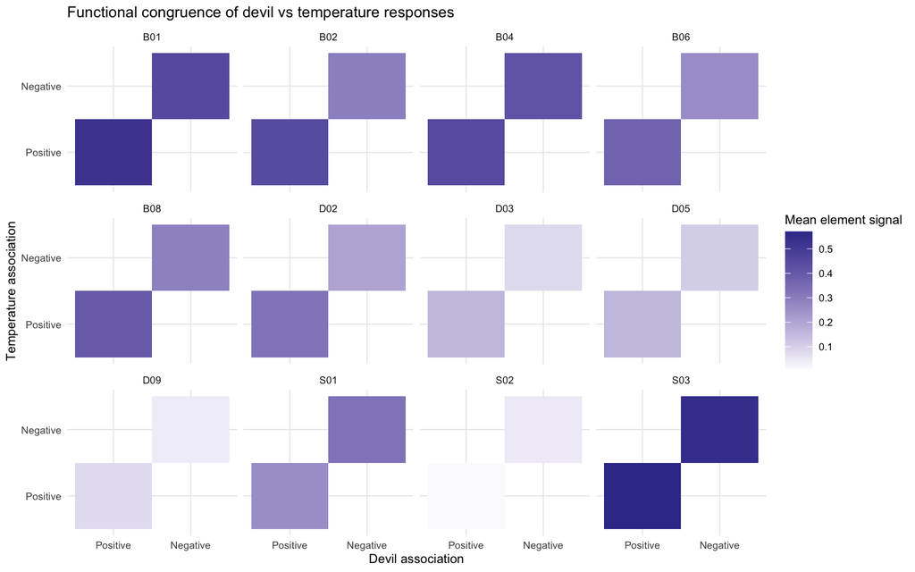

```r
# elements_response has: genome, GIFT, value, and trend columns (devil, temperature, ...)
# Focus on non-neutral responses for both variables
elem_dev_temp <- elements_response %>%
  filter(devil != "Neutral",
         temperature != "Neutral") %>%
  mutate(
    devil      = droplevels(devil),
    temperature = droplevels(temperature)
  )

# Summarise at the element level: mean value per devil/temperature combo
func_congruence_elem <- elem_dev_temp %>%
  group_by(GIFT, devil, temperature) %>%
  summarise(
    mean_val = mean(value, na.rm = TRUE),
    n        = n(),
    .groups  = "drop"
  )

# Collapse to functional group (Code_function)
func_congruence_group <- func_congruence_elem %>%
  left_join(
    GIFT_db %>% distinct(Code_element, Code_function, Function),
    by = c("GIFT" = "Code_element")
  ) %>%
  group_by(Code_function, devil, temperature) %>%
  summarise(
    mean_val = mean(mean_val, na.rm = TRUE),
    .groups  = "drop"
  )

# For readability, keep only functional groups that show some variation
interesting_funcs <- func_congruence_group %>%
  group_by(Code_function) %>%
  summarise(range_val = max(mean_val) - min(mean_val), .groups = "drop") %>%
  slice_max(order_by = range_val, n = 12) %>%
  pull(Code_function)

func_congruence_group %>%
  filter(Code_function %in% interesting_funcs) %>%
  ggplot(aes(x = devil, y = temperature, fill = mean_val)) +
  geom_tile() +
  facet_wrap(~ Code_function) +
  scale_fill_gradient2() +
  labs(
    x = "Devil association",
    y = "Temperature association",
    fill = "Mean element signal",
    title = "Functional congruence of devil vs temperature responses"
  ) +
  theme_minimal(base_size = 8)
```

## 14.13 Association with devil

**Note:** Summarize devil associations across taxonomic levels. Count positive and negative associations with devil presence and calculate percentages at phylum, order, family, and genus levels to identify taxonomic groups most strongly associated with devil.

```r
post_table$devil %>% table()
```

```
## .
## Positive  Neutral Negative
##      130      341      105
```

```r
devil_phylum_perc <- post_table %>%
  rownames_to_column(var = "genome") %>%
  left_join(genome_metadata, by = "genome") %>%
  group_by(phylum) %>%
  summarise(positive = sum(devil == "Positive"),
            percent_positive = mean(devil == "Positive") * 100,
            negative = sum(devil == "Negative"),
            percent_negative = mean(devil == "Negative") * 100)

devil_phylum_perc %>%
  arrange(-percent_positive)
```

```
## # A tibble: 13 × 5
##    phylum               positive percent_positive negative percent_negative
##    <chr>                   <int>            <dbl>    <int>            <dbl>
##  1 p__Actinomycetota           1            33.3         0             0
##  2 p__Pseudomonadota           4            28.6         3            21.4
##  3 p__Bacillota_A            117            25.6        72            15.8
##  4 p__Bacillota                5            17.2        15            51.7
##  5 p__Cyanobacteriota          3             6.67        2             4.44
##  6 p__Bacillota_B              0             0           1           100
##  7 p__Bacillota_C              0             0           0             0
##  8 p__Bacteroidota             0             0           7            70
##  9 p__Campylobacterota         0             0           1           100
## 10 p__Desulfobacterota         0             0           1            50
## 11 p__Synergistota             0             0           2            33.3
## 12 p__Thermoplasmatota         0             0           0             0
## 13 p__Verrucomicrobiota        0             0           1           100
```

```r
devil_phylum_perc %>%
  arrange(-percent_negative)
```

```
## # A tibble: 13 × 5
##    phylum               positive percent_positive negative percent_negative
##    <chr>                   <int>            <dbl>    <int>            <dbl>
##  1 p__Bacillota_B              0             0           1           100
##  2 p__Campylobacterota         0             0           1           100
##  3 p__Verrucomicrobiota        0             0           1           100
##  4 p__Bacteroidota             0             0           7            70
##  5 p__Bacillota                5            17.2        15            51.7
##  6 p__Desulfobacterota         0             0           1            50
##  7 p__Synergistota             0             0           2            33.3
##  8 p__Pseudomonadota           4            28.6         3            21.4
##  9 p__Bacillota_A            117            25.6        72            15.8
## 10 p__Cyanobacteriota          3             6.67        2             4.44
## 11 p__Actinomycetota           1            33.3         0             0
## 12 p__Bacillota_C              0             0           0             0
## 13 p__Thermoplasmatota         0             0           0             0
```

```r
# Sub-phylum level

post_table %>%
  rownames_to_column(var = "genome") %>%
  left_join(genome_metadata, by = "genome") %>%
  filter(phylum=="p__Bacillota_A") %>%
  group_by(order) %>%
  summarise(positive = sum(devil == "Positive"),
            percent_positive = mean(devil == "Positive") * 100,
            negative = sum(devil == "Negative"),
            percent_negative = mean(devil == "Negative") * 100) %>%
  arrange(-percent_positive)
```

```
## # A tibble: 8 × 5
##   order                   positive percent_positive negative percent_negative
##   <chr>                      <int>            <dbl>    <int>            <dbl>
## 1 o__UMGS1883                    6            100          0             0
## 2 o__UBA1381                     7             70          0             0
## 3 o__Oscillospirales            49             39.2       15            12
## 4 o__Lachnospirales             55             29.9       28            15.2
## 5 o__Christensenellales          0              0          3             3.70
## 6 o__Monoglobales                0              0          1            33.3
## 7 o__Peptostreptococcales        0              0          0             0
## 8 o__TANB77                      0              0         25            53.2
```

```r
post_table %>%
  rownames_to_column(var = "genome") %>%
  left_join(genome_metadata, by = "genome") %>%
  filter(order=="o__TANB77") %>%
  group_by(family) %>%
  summarise(positive = sum(devil == "Positive"),
            percent_positive = mean(devil == "Positive") * 100,
            negative = sum(devil == "Negative"),
            percent_negative = mean(devil == "Negative") * 100) %>%
  arrange(-percent_positive)
```

```
## # A tibble: 2 × 5
##   family     positive percent_positive negative percent_negative
##   <chr>         <int>            <dbl>    <int>            <dbl>
## 1 f__CAG-465        0                0        6            100
## 2 f__CAG-508        0                0       19             46.3
```

```r
post_table %>%
  rownames_to_column(var = "genome") %>%
  left_join(genome_metadata, by = "genome") %>%
  filter(family=="f__CAG-508") %>%
  group_by(genus) %>%
  summarise(positive = sum(devil == "Positive"),
            percent_positive = mean(devil == "Positive") * 100,
            negative = sum(devil == "Negative"),
            percent_negative = mean(devil == "Negative") * 100) %>%
  arrange(-percent_positive)
```

```
## # A tibble: 9 × 5
##   genus          positive percent_positive negative percent_negative
##   <chr>             <int>            <dbl>    <int>            <dbl>
## 1 g__                   0                0        1            100
## 2 g__CAG-269            0                0        5             41.7
## 3 g__CAG-273            0                0        1             33.3
## 4 g__CAG-492            0                0        0              0
## 5 g__CAG-793            0                0        0              0
## 6 g__CAKPSH01           0                0        0              0
## 7 g__JAAWPK01           0                0        1             33.3
## 8 g__Scatovivens        0                0        9             64.3
## 9 g__UMGS1994           0                0        2             50
```

## 14.14 Devil beta coefficients

**Note:** Extract posterior mean beta coefficients and support values for the devil covariate. Create a scatter plot showing beta coefficient (x-axis) versus posterior probability (y-axis), colored by phylum for genomes with significant associations. This visualization helps identify genomes with strong and well-supported devil associations.

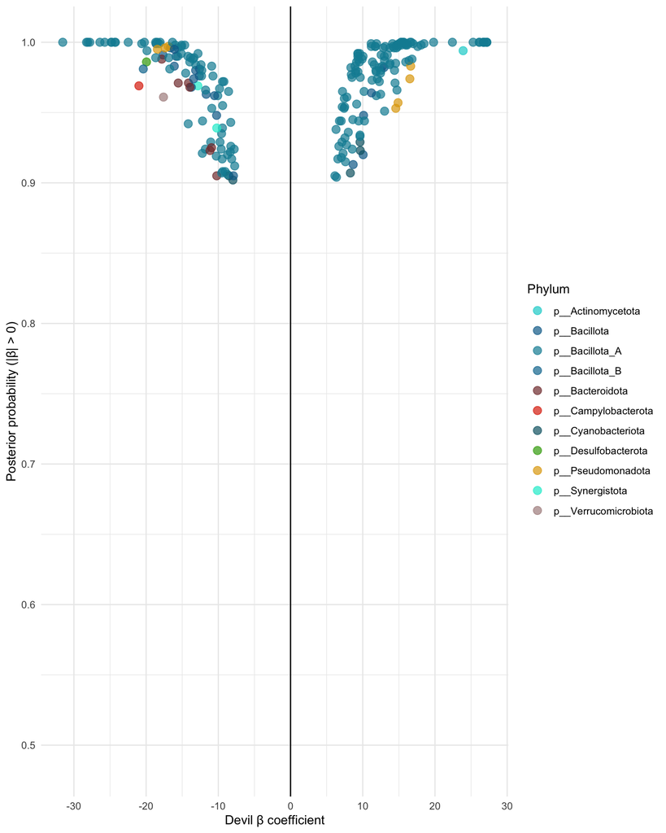

```r
# Extract beta estimate and support using helper functions
devil_estimate <- get_beta_estimate(fit_model_18, m, "devil")
devil_support <- get_beta_support(fit_model_18, m, "devil")

devil_beta <- inner_join(devil_estimate, devil_support, by = "genome") %>%
  left_join(genome_metadata, by = "genome")

# Optional: precompute x-limits if you really want them
devil_xrange <- range(devil_beta$mean, na.rm = TRUE)
devil_xlim   <- devil_xrange + c(-0.05, 0.05)

devil_beta %>%
  mutate(
    significant   = support >= support_threshold | support <= negsupport_threshold,
    support_plot  = ifelse(mean < 0, 1 - support, support), # support for the sign of beta
    phylum_sig    = ifelse(significant & support_plot > 0.9, phylum, NA)
  ) %>%
  ggplot(aes(x = mean, y = support_plot, colour = phylum_sig)) +
  geom_point(alpha = 0.7, size = 3) +
  scale_color_manual(values = phylum_colors, na.translate = FALSE) +
  geom_vline(xintercept = 0) +
  # if you want the x-limits, now this is safe:
  xlim(devil_xlim) +
  labs(
    x = "Devil β coefficient",
    y = "Posterior probability (|β| > 0)",
    colour = "Phylum"
  ) +
  theme_minimal()
```

## Devil credible intervals

**Note:** Calculate 10% and 90% credible intervals for devil beta coefficients. Filter to genomes with credible non-zero effects (where the credible interval does not include zero) and create a forest plot showing beta estimates with error bars, ordered by effect size.

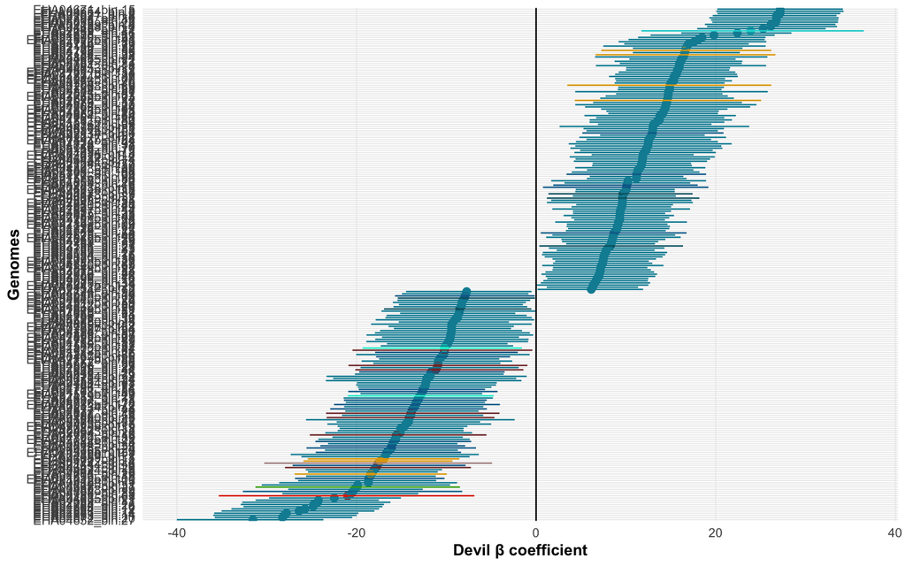

```r
# Credible intervals for 'devil' using helper function
devil_estimate <- get_beta_estimate(fit_model_18, m, "devil")
devil_ci <- get_beta_ci(fit_model_18, m, "devil") %>%
  right_join(devil_estimate, by = "genome") %>%
  left_join(genome_metadata, by = "genome")

# Genomes with credible non-zero devil effect
devil_ci %>%
  filter(q10 > 0 | q90 < 0) %>%
  create_forest_plot(
    color_var = "phylum",
    color_values = phylum_colors,
    x_lab = "Devil β coefficient",
    y_lab = "Genomes",
    show_legend = FALSE
  )
```

## Devil top genomes

**Note:** Identify the top 30 genomes with the strongest positive and top 30 with the strongest negative devil associations (based on credible intervals). Create a focused forest plot showing only these top genomes with their credible intervals, providing a clear view of the most extreme devil associations.

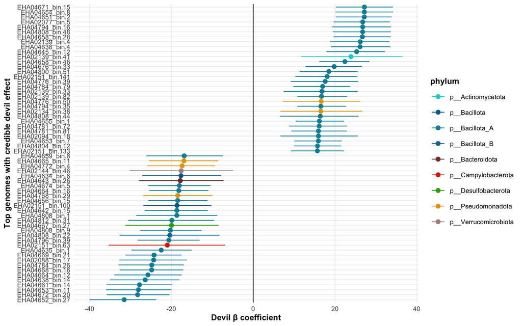

```r
# Reuse devil_ci from previous chunk if available, otherwise create it
if (!exists("devil_ci")) {
  devil_estimate <- get_beta_estimate(fit_model_18, m, "devil")
  devil_ci <- get_beta_ci(fit_model_18, m, "devil") %>%
    right_join(devil_estimate, by = "genome") %>%
    left_join(genome_metadata, by = "genome")
}

# Keep only genomes with credible non-zero effect
devil_ci_sig <- devil_ci %>%
  filter(q10 > 0 | q90 < 0)

# 4. Take top N positive and top N negative genomes
N_top <- 30

devil_ci_top <- devil_ci_sig %>%
  slice_max(order_by = mean, n = N_top, with_ties = FALSE) %>%
  bind_rows(
    devil_ci_sig %>%
      slice_min(order_by = mean, n = N_top, with_ties = FALSE)
  ) %>%
  distinct(genome, .keep_all = TRUE)

# 5. Plot
devil_ci_top %>%
  create_forest_plot(
    color_var = "phylum",
    color_values = phylum_colors,
    x_lab = "Devil β coefficient",
    y_lab = "Top genomes with credible devil effect",
    base_size = 9,
    errorbar_width = 0,
    show_legend = TRUE
  )
```

## Devil phylum-level summary

**Note:** Aggregate devil beta coefficients at the phylum level by calculating mean beta and credible intervals (10th and 90th percentiles) for each phylum. Create a forest plot showing phylum-level devil associations to identify which phyla are generally positively or negatively associated with devil presence.

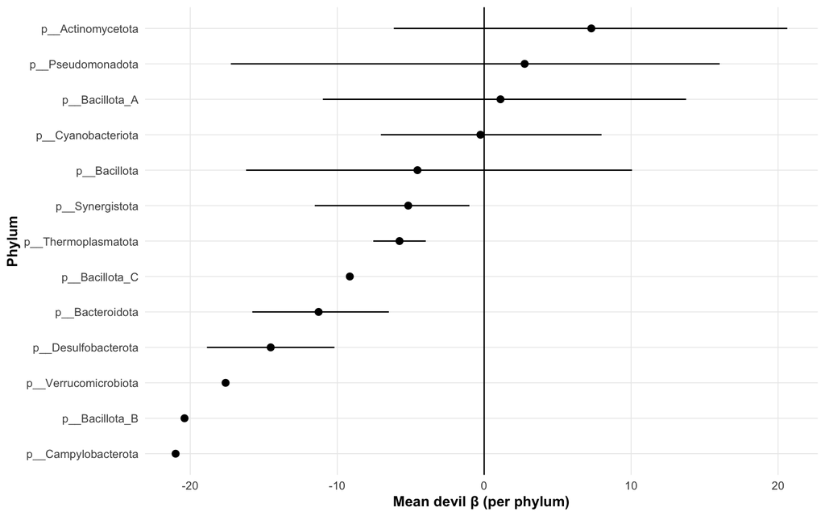

```r
devil_phylum_ci <- aggregate_by_taxonomy(devil_ci, tax_level = "phylum")

devil_phylum_ci %>%
  create_forest_plot(
    x_var = "mean_beta",
    xmin_var = "q10",
    xmax_var = "q90",
    y_var = "phylum",
    x_lab = "Mean devil β (per phylum)",
    y_lab = "Phylum",
    show_legend = FALSE
  )
```

## Devil association overview

**Note:** Create summary tables of genomes with credible positive and negative devil associations. Display full taxonomic information (phylum through species) along with beta coefficients and credible intervals. These tables provide a comprehensive overview of all genomes significantly associated with devil presence.

```r
devil_positive <- devil_ci %>%
  filter(q10 > 0) %>%
  arrange(-mean) %>%
  dplyr::select(genome, phylum, class, order, family, genus, species, mean, q10, q90)

devil_negative <- devil_ci %>%
  filter(q90 < 0) %>%
  arrange(mean) %>%
  dplyr::select(genome, phylum, class, order, family, genus, species, mean, q10, q90)

devil_positive %>% tt()  # tinytable
```

| genome | phylum | class | order | family | genus | species | mean | q10 | q90 |
| --- | --- | --- | --- | --- | --- | --- | --- | --- | --- |
| EHA04671_bin.15 | p__Bacillota_A | c__Clostridia | o__Oscillospirales | f__Oscillospiraceae | g__JAJQCF01 | s__JAJQCF01 sp021202845 | 27.184759 | 20.17756683 | 34.16605 |
| EHA04654_bin.8 | p__Bacillota_A | c__Clostridia | o__Oscillospirales | f__Oscillospiraceae | g__JAJQCF01 | s__JAJQCF01 sp021202845 | 27.178157 | 20.07747483 | 34.24386 |
| EHA04651_bin.2 | p__Bacillota_A | c__Clostridia | o__Oscillospirales | f__Oscillospiraceae | g__JAJQCF01 | s__JAJQCF01 sp021202845 | 27.162169 | 20.19045734 | 33.87392 |
| EHA02077_bin.5 | p__Bacillota_A | c__Clostridia | o__Oscillospirales | f__Oscillospiraceae | g__JAJQCF01 | s__JAJQCF01 sp021202845 | 26.775095 | 19.67148071 | 33.46267 |
| EHA04794_bin.16 | p__Bacillota_A | c__Clostridia | o__Oscillospirales | f__Oscillospiraceae | g__JAJQCF01 | s__JAJQCF01 sp021202845 | 26.771727 | 19.29150397 | 33.69468 |
| EHA04808_bin.48 | p__Bacillota_A | c__Clostridia | o__Oscillospirales | f__Oscillospiraceae | g__JAJQCF01 | s__JAJQCF01 sp021202845 | 26.753844 | 19.49007623 | 33.65650 |
| EHA04658_bin.28 | p__Bacillota_A | c__Clostridia | o__Oscillospirales | f__Oscillospiraceae | g__JAJQCF01 | s__JAJQCF01 sp021202845 | 26.690682 | 19.61813071 | 33.62124 |
| EHA02139_bin.4 | p__Bacillota_A | c__Clostridia | o__Oscillospirales | f__Oscillospiraceae | g__JAJQCF01 | s__JAJQCF01 sp021202845 | 26.167823 | 18.79967306 | 33.34084 |
| EHA04638_bin.4 | p__Bacillota_A | c__Clostridia | o__Oscillospirales | f__Oscillospiraceae | g__JAJQCF01 | s__JAJQCF01 sp021202845 | 26.124049 | 19.04186828 | 33.51898 |
| EHA04645_bin.12 | p__Bacillota_A | c__Clostridia | o__Oscillospirales | f__Oscillospiraceae | g__JAJQCF01 | s__JAJQCF01 sp021202845 | 25.284487 | 17.94213395 | 32.24668 |
| EHA02139_bin.41 | p__Actinomycetota | c__Coriobacteriia | o__Coriobacteriales | f__Eggerthellaceae | g__CAJFUR01 | s__ | 23.896940 | 11.72860322 | 36.49790 |
| EHA04658_bin.46 | p__Bacillota_A | c__Clostridia | o__Lachnospirales | f__Lachnospiraceae | g__Choladousia | s__ | 22.413241 | 16.16607675 | 28.43613 |
| EHA04676_bin.33 | p__Bacillota_A | c__Clostridia | o__Lachnospirales | f__Lachnospiraceae | g__Eubacterium_I | s__Eubacterium_I sp021205085 | 19.806369 | 12.74827367 | 26.57508 |
| EHA04800_bin.51 | p__Bacillota_A | c__Clostridia | o__Lachnospirales | f__Lachnospiraceae | g__Eubacterium_I | s__Eubacterium_I sp021205085 | 18.484305 | 11.35588498 | 25.54873 |
| EHA02151_bin.141 | p__Bacillota_A | c__Clostridia | o__Lachnospirales | f__Lachnospiraceae | g__Choladousia | s__ | 18.077379 | 10.28926328 | 25.45815 |
| EHA04776_bin.39 | p__Bacillota_A | c__Clostridia | o__Oscillospirales | f__Oscillospiraceae | g__JAJQBJ01 | s__JAJQBJ01 sp021203345 | 17.608907 | 9.18100946 | 25.64372 |
| EHA04784_bin.79 | p__Bacillota_A | c__Clostridia | o__Lachnospirales | f__Lachnospiraceae | g__Eubacterium_I | s__ | 16.978200 | 9.81547060 | 23.67954 |
| EHA02139_bin.33 | p__Bacillota_A | c__Clostridia | o__Oscillospirales | f__Oscillospiraceae | g__CAJOIG01 | s__CAJOIG01 sp021205095 | 16.819068 | 7.48008946 | 25.56642 |
| EHA02139_bin.82 | p__Bacillota_A | c__Clostridia | o__Lachnospirales | f__Lachnospiraceae | g__Choladousia | s__ | 16.702146 | 10.77339966 | 22.98318 |
| EHA04776_bin.50 | p__Pseudomonadota | c__Gammaproteobacteria | o__Burkholderiales | f__Burkholderiaceae | g__Oxalobacter | s__Oxalobacter sp900760095 | 16.634255 | 7.24978772 | 26.19528 |
| EHA04794_bin.35 | p__Bacillota_A | c__Clostridia | o__Oscillospirales | f__Oscillospiraceae | g__Onthomonas | s__Onthomonas sp021201185 | 16.541005 | 10.77165340 | 22.69227 |
| EHA02134_bin.38 | p__Pseudomonadota | c__Gammaproteobacteria | o__Burkholderiales | f__Burkholderiaceae | g__Oxalobacter | s__Oxalobacter sp900760095 | 16.521010 | 6.62266571 | 26.64820 |
| EHA04808_bin.44 | p__Bacillota_A | c__Clostridia | o__UBA1381 | f__UBA1381 | g__UBA4716 | s__ | 16.402196 | 6.56260106 | 25.75758 |
| EHA04655_bin.1 | p__Bacillota_A | c__Clostridia | o__Oscillospirales | f__Oscillospiraceae | g__Onthomonas | s__Onthomonas sp021205725 | 16.169994 | 10.37799111 | 22.21818 |
| EHA04781_bin.72 | p__Bacillota_A | c__Clostridia | o__Oscillospirales | f__Oscillospiraceae | g__Onthomonas | s__ | 16.135348 | 8.74338820 | 22.96760 |
| EHA04781_bin.81 | p__Bacillota_A | c__Clostridia | o__Lachnospirales | f__Lachnospiraceae | g__Choladousia | s__Choladousia sp020859985 | 15.962378 | 9.31610644 | 22.90079 |
| EHA02094_bin.18 | p__Bacillota_A | c__Clostridia | o__UMGS1883 | f__UMGS1883 | g__JAJQCX01 | s__ | 15.951408 | 6.65800696 | 25.61942 |
| EHA04653_bin.7 | p__Bacillota_A | c__Clostridia | o__Oscillospirales | f__Oscillospiraceae | g__Onthomonas | s__Onthomonas sp021205725 | 15.940849 | 10.03304814 | 21.61345 |
| EHA04804_bin.12 | p__Bacillota_A | c__Clostridia | o__Oscillospirales | f__Oscillospiraceae | g__Onthomonas | s__Onthomonas sp021201185 | 15.729797 | 10.00639549 | 21.52432 |
| EHA02151_bin.133 | p__Bacillota_A | c__Clostridia | o__Lachnospirales | f__Lachnospiraceae | g__Choladousia | s__ | 15.692470 | 9.19200494 | 22.18617 |

[output cut: 100 more lines]

```r
devil_negative %>% tt()
```

| genome | phylum | class | order | family | genus | species | mean | q10 | q90 |
| --- | --- | --- | --- | --- | --- | --- | --- | --- | --- |
| EHA04652_bin.27 | p__Bacillota_A | c__Clostridia | o__Lachnospirales | f__Lachnospiraceae | g__Coprococcus | s__ | -31.547113 | -40.01003 | -23.68511059 |
| EHA04672_bin.20 | p__Bacillota_A | c__Clostridia | o__Lachnospirales | f__Lachnospiraceae | g__Coprococcus | s__ | -28.250892 | -35.78880 | -20.47958447 |
| EHA04653_bin.11 | p__Bacillota_A | c__Clostridia | o__Lachnospirales | f__Lachnospiraceae | g__Coprococcus | s__ | -28.066605 | -35.95747 | -19.98360950 |
| EHA04661_bin.14 | p__Bacillota_A | c__Clostridia | o__Lachnospirales | f__Lachnospiraceae | g__Coprococcus | s__ | -27.797529 | -35.85412 | -19.79099746 |
| EHA04638_bin.14 | p__Bacillota_A | c__Clostridia | o__Lachnospirales | f__Lachnospiraceae | g__Coprococcus | s__ | -26.401353 | -35.03113 | -18.01354980 |
| EHA04664_bin.12 | p__Bacillota_A | c__Clostridia | o__Lachnospirales | f__Lachnospiraceae | g__Coprococcus | s__ | -25.731093 | -33.93420 | -17.48397018 |
| EHA04668_bin.16 | p__Bacillota_A | c__Clostridia | o__Lachnospirales | f__Lachnospiraceae | g__Coprococcus | s__ | -24.825894 | -32.59480 | -17.11659002 |
| EHA04784_bin.26 | p__Bacillota_A | c__Clostridia | o__Lachnospirales | f__Lachnospiraceae | g__Coprococcus | s__ | -24.788365 | -32.89614 | -16.94968652 |
| EHA02088_bin.17 | p__Bacillota_A | c__Clostridia | o__Lachnospirales | f__Lachnospiraceae | g__Coprococcus | s__ | -24.326182 | -32.73127 | -16.22305563 |
| EHA04669_bin.21 | p__Bacillota_A | c__Clostridia | o__TANB77 | f__CAG-465 | g__CAG-465 | s__ | -24.246888 | -31.23407 | -17.50742699 |
| EHA04635_bin.1 | p__Bacillota_A | c__Clostridia | o__TANB77 | f__CAG-465 | g__CAG-465 | s__ | -22.478204 | -29.74206 | -15.05445341 |
| EHA02151_bin.63 | p__Campylobacterota | c__Campylobacteria | o__Campylobacterales | f__Helicobacteraceae | g__Helicobacter_A | s__ | -20.998356 | -35.34315 | -6.87705777 |
| EHA04796_bin.39 | p__Bacillota_A | c__Clostridia | o__TANB77 | f__CAG-465 | g__CAG-465 | s__ | -20.610243 | -28.26491 | -13.12373507 |
| EHA04808_bin.22 | p__Bacillota_B | c__Peptococcia | o__Peptococcales | f__Peptococcaceae | g__UBA7185 | s__ | -20.392536 | -32.66030 | -8.23033992 |
| EHA04808_bin.9 | p__Bacillota_A | c__Clostridia | o__TANB77 | f__CAG-465 | g__CAG-465 | s__ | -20.237483 | -27.60328 | -12.62479684 |
| EHA04667_bin.27 | p__Desulfobacterota | c__Desulfovibrionia | o__Desulfovibrionales | f__Desulfovibrionaceae | g__Desulfovibrio | s__ | -19.949511 | -31.25834 | -8.48060027 |
| EHA04812_bin.31 | p__Bacillota_A | c__Clostridia | o__Lachnospirales | f__Lachnospiraceae | g__Butyribacter | s__ | -19.884009 | -30.55508 | -9.58503334 |
| EHA04808_bin.1 | p__Bacillota_A | c__Clostridia | o__Lachnospirales | f__Lachnospiraceae | g__Butyribacter | s__ | -18.678793 | -28.61070 | -8.80611379 |
| EHA04642_bin.15 | p__Bacillota_A | c__Clostridia | o__Lachnospirales | f__CAG-274 | g__JAJQCI01 | s__ | -18.674453 | -26.50373 | -11.12338561 |
| EHA02151_bin.100 | p__Bacillota | c__Bacilli | o__RF39 | f__UBA660 | g__Coprovivens | s__ | -18.627065 | -26.85473 | -10.20382133 |
| EHA04656_bin.15 | p__Bacillota_A | c__Clostridia | o__TANB77 | f__CAG-465 | g__CAG-465 | s__ | -18.471434 | -25.61748 | -11.17311983 |
| EHA04768_bin.29 | p__Pseudomonadota | c__Gammaproteobacteria | o__Burkholderiales | f__Burkholderiaceae_A | g__JAJPXW01 | s__ | -18.440226 | -26.89307 | -9.94717178 |
| EHA04664_bin.16 | p__Bacillota_A | c__Clostridia | o__TANB77 | f__CAG-465 | g__CAG-465 | s__ | -18.187591 | -25.41008 | -10.94895114 |
| EHA04674_bin.5 | p__Bacillota_A | c__Clostridia | o__Lachnospirales | f__CAG-274 | g__JAJQCI01 | s__ | -18.057302 | -25.65967 | -10.48217060 |
| EHA04643_bin.26 | p__Bacteroidota | c__Bacteroidia | o__Bacteroidales | f__Bacteroidaceae | g__Bacteroides | s__ | -17.830338 | -27.96509 | -7.26287149 |
| EHA04634_bin.6 | p__Bacillota | c__Bacilli | o__RF39 | f__UBA660 | g__SIG200 | s__ | -17.666759 | -27.12130 | -7.85564111 |
| EHA02144_bin.46 | p__Verrucomicrobiota | c__Verrucomicrobiae | o__Verrucomicrobiales | f__Akkermansiaceae | g__Akkermansia | s__Akkermansia sp021200315 | -17.596825 | -30.27724 | -4.90413298 |
| EHA04772_bin.4 | p__Pseudomonadota | c__Gammaproteobacteria | o__Burkholderiales | f__Burkholderiaceae_A | g__JAJPXW01 | s__ | -17.370046 | -25.91212 | -9.31319523 |
| EHA04665_bin.11 | p__Pseudomonadota | c__Gammaproteobacteria | o__Burkholderiales | f__Burkholderiaceae_A | g__JAJPXW01 | s__ | -16.937619 | -25.43126 | -8.54425400 |
| EHA04659_bin.8 | p__Bacillota_A | c__Clostridia | o__Oscillospirales | f__Ruminococcaceae | g__Ruminococcus_D | s__Ruminococcus_D sp021199375 | -16.860720 | -26.13773 | -7.40369223 |

[output cut: 76 more lines]

## 14.15 Devil functional differences

**Note:** Compare functional element abundances between genomes with positive versus negative devil associations. For each GIFT element, calculate mean abundances in positive and negative groups, compute differences, and perform t-tests with Benjamini-Hochberg FDR correction to identify functional elements significantly enriched in one group.

```r
functional_differences_devil <- calculate_functional_differences(
  elements_response,
  variable_name = "devil"
)
```

## 14.16 Devil functional differences volcano plot

**Note:** Create a volcano plot visualizing functional differences between positive and negative devil-associated genomes. Plot mean difference (x-axis) versus negative log10 FDR (y-axis), colored by functional group. Highlight significant functional elements that exceed both fold-change and FDR thresholds, with labels for the most significant hits.

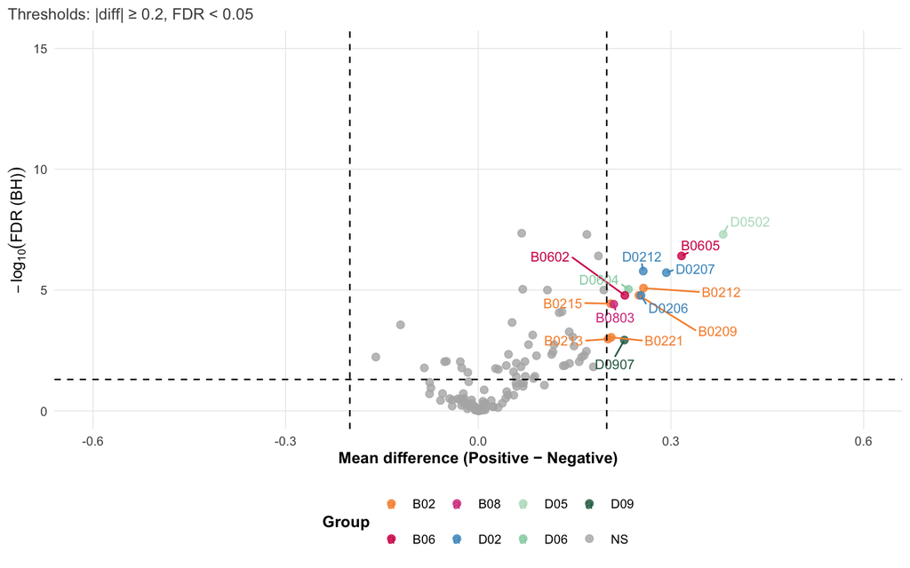

```r
create_volcano_plot(
  functional_differences_devil,
  variable_label = "Devil",
  gift_colors = gift_colors
)
```

## 14.17 Build devil credible intervals (all genomes)

**Note:** Extract posterior mean and 10%/90% credible intervals for devil beta coefficients across all genomes in the model. Create a comprehensive dataset with genome names, mean beta, and credible interval bounds for downstream functional-level aggregations.

```r
# Posterior mean and 10/90% credible intervals for the "devil" covariate
# across all genomes using helper function
devil_ci_all <- get_beta_complete(fit_model_18, m, "devil")

devil_ci_all
```

```
## # A tibble: 576 × 14
##    genome            q10   q90   mean domain phylum class order family genus species completeness
##    <chr>           <dbl> <dbl>  <dbl> <chr>  <chr>  <chr> <chr> <chr>  <chr> <chr>          <dbl>
##  1 EHA02075_bin…  -3.00  13.4   5.52  d__Ba… p__Ba… c__C… o__O… f__Ru… g__F… s__            100
##  2 EHA02075_bin…  -6.18  13.1   3.56  d__Ba… p__Ba… c__B… o__R… f__CA… g__E… s__             91.2
##  3 EHA02075_bin… -12.7   10.5  -0.912 d__Ba… p__Sy… c__S… o__S… f__Sy… g__E… s__             99.7
##  4 EHA02075_bin…  -4.15  10.0   3.00  d__Ba… p__Ba… c__C… o__C… f__Bo… g__C… s__             94.6
##  5 EHA02075_bin…   0.516 12.7   6.55  d__Ba… p__Ba… c__C… o__O… f__Os… g__O… s__             57.2
##  6 EHA02075_bin…   8.90  20.8  14.7   d__Ba… p__Ba… c__C… o__O… f__Os… g__O… s__Ont…         74.8
##  7 EHA02075_bin…  -8.36   5.12 -1.83  d__Ba… p__Cy… c__V… o__G… f__Ga… g__A… s__             50.1
##  8 EHA02075_bin…  -4.13   6.85  1.22  d__Ba… p__Ba… c__C… o__L… f__La… g__V… s__Ven…         65.4
##  9 EHA02075_bin… -17.2    1.97 -7.70  d__Ba… p__Ba… c__C… o__O… f__Ru… g__U… s__UMG…         99.9
## 10 EHA02076_bin…   4.31  25.1  14.6   d__Ba… p__Ps… c__G… o__B… f__Bu… g__M… s__             84.0
## # ℹ 566 more rows
## # ℹ 2 more variables: contamination <dbl>, length <dbl>
```

## 14.18 Devil functional group forest plot

**Note:** Aggregate devil beta coefficients by functional group (GIFT 3-letter codes). For each functional group, calculate mean beta across all genomes carrying that function, along with credible intervals. Select top 15 positive and top 15 negative functional groups and create a forest plot showing functional-level devil associations with appropriate color coding.

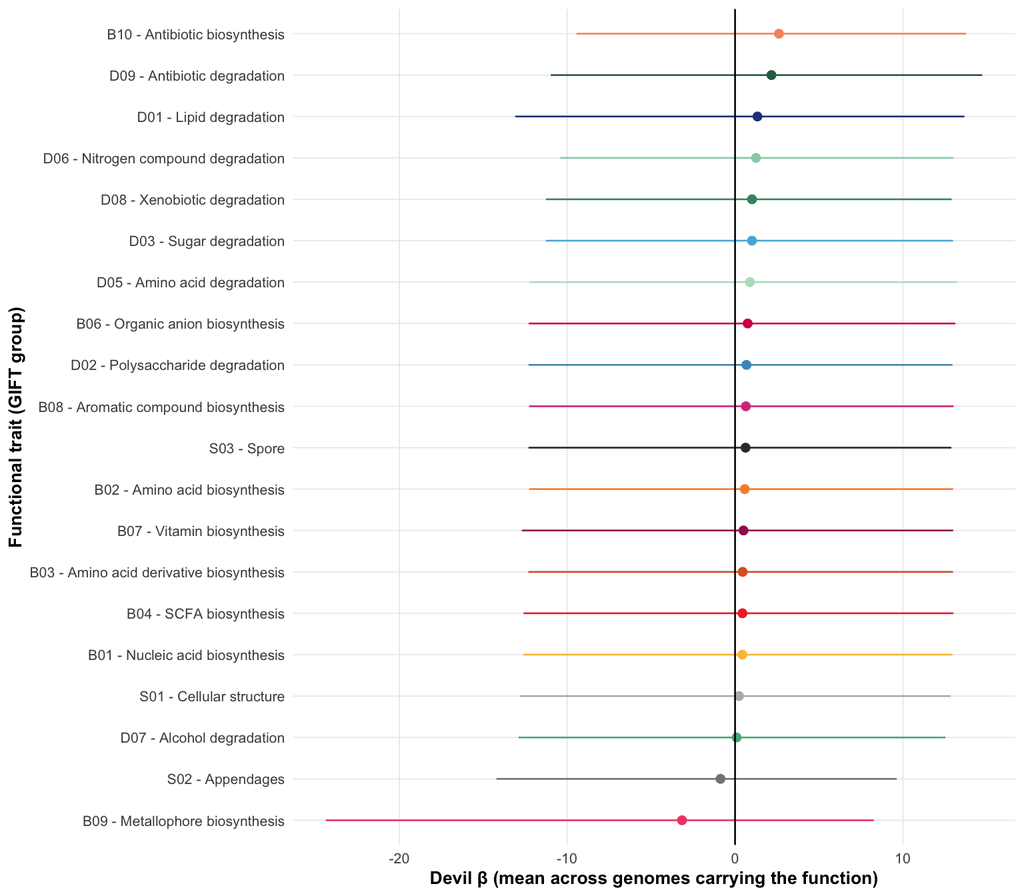

```r
# Aggregate by functional group using helper function
devil_func_top <- aggregate_by_function(
  devil_ci_all,
  elements_response,
  gift_colors,
  n_top = 15
)

# Create forest plot
func_cols <- setNames(devil_func_top$color, devil_func_top$func_label)

devil_func_top %>%
  create_forest_plot(
    x_var = "mean_beta",
    xmin_var = "q10_fun",
    xmax_var = "q90_fun",
    y_var = "func_label",
    color_var = "func_label",
    color_values = func_cols,
    x_lab = "Devil β (mean across genomes carrying the function)",
    y_lab = "Functional trait (GIFT group)",
    base_size = 10,
    errorbar_width = 0,
    show_legend = FALSE
  )
```

## 14.19 Association with temperature

**Note:** Summarize temperature associations across taxonomic levels. Count positive and negative associations with temperature and calculate percentages at phylum, order, family, and genus levels to identify taxonomic groups most strongly associated with temperature variation.

```r
post_table$temperature %>% table()
```

```
## .
## Positive  Neutral Negative
##      139      303      134
```

```r
temp_phylum_perc <- post_table %>%
  rownames_to_column(var = "genome") %>%
  left_join(genome_metadata, by = "genome") %>%
  group_by(phylum) %>%
  summarise(positive = sum(temperature == "Positive"),
            percent_positive = mean(temperature == "Positive") * 100,
            negative = sum(temperature == "Negative"),
            percent_negative = mean(temperature == "Negative") * 100)

temp_phylum_perc %>%
  arrange(-percent_positive)
```

```
## # A tibble: 13 × 5
##    phylum               positive percent_positive negative percent_negative
##    <chr>                   <int>            <dbl>    <int>            <dbl>
##  1 p__Pseudomonadota           5            35.7         4             28.6
##  2 p__Actinomycetota           1            33.3         0              0
##  3 p__Bacillota_A            128            28.0        89             19.5
##  4 p__Bacillota                4            13.8        15             51.7
##  5 p__Cyanobacteriota          1             2.22       12             26.7
##  6 p__Bacillota_B              0             0           1            100
##  7 p__Bacillota_C              0             0           0              0
##  8 p__Bacteroidota             0             0           4             40
##  9 p__Campylobacterota         0             0           1            100
## 10 p__Desulfobacterota         0             0           0              0
## 11 p__Synergistota             0             0           1             16.7
## 12 p__Thermoplasmatota         0             0           6            100
## 13 p__Verrucomicrobiota        0             0           1            100
```

```r
temp_phylum_perc %>%
  arrange(-percent_negative)
```

```
## # A tibble: 13 × 5
##    phylum               positive percent_positive negative percent_negative
##    <chr>                   <int>            <dbl>    <int>            <dbl>
##  1 p__Bacillota_B              0             0           1            100
##  2 p__Campylobacterota         0             0           1            100
##  3 p__Thermoplasmatota         0             0           6            100
##  4 p__Verrucomicrobiota        0             0           1            100
##  5 p__Bacillota                4            13.8        15             51.7
##  6 p__Bacteroidota             0             0           4             40
##  7 p__Pseudomonadota           5            35.7         4             28.6
##  8 p__Cyanobacteriota          1             2.22       12             26.7
##  9 p__Bacillota_A            128            28.0        89             19.5
## 10 p__Synergistota             0             0           1             16.7
## 11 p__Actinomycetota           1            33.3         0              0
## 12 p__Bacillota_C              0             0           0              0
## 13 p__Desulfobacterota         0             0           0              0
```

```r
# Sub-phylum level

post_table %>%
  rownames_to_column(var = "genome") %>%
  left_join(genome_metadata, by = "genome") %>%
  filter(phylum=="p__Bacillota_A") %>%
  group_by(order) %>%
  summarise(positive = sum(temperature == "Positive"),
            percent_positive = mean(temperature == "Positive") * 100,
            negative = sum(temperature == "Negative"),
            percent_negative = mean(temperature == "Negative") * 100) %>%
  arrange(-percent_positive)
```

```
## # A tibble: 8 × 5
##   order                   positive percent_positive negative percent_negative
##   <chr>                      <int>            <dbl>    <int>            <dbl>
## 1 o__UMGS1883                    6            100          0              0
## 2 o__UBA1381                     7             70          0              0
## 3 o__Lachnospirales             76             41.3       41             22.3
## 4 o__Oscillospirales            39             31.2       13             10.4
## 5 o__Christensenellales          0              0         10             12.3
## 6 o__Monoglobales                0              0          1             33.3
## 7 o__Peptostreptococcales        0              0          0              0
## 8 o__TANB77                      0              0         24             51.1
```

```r
post_table %>%
  rownames_to_column(var = "genome") %>%
  left_join(genome_metadata, by = "genome") %>%
  filter(order=="o__TANB77") %>%
  group_by(family) %>%
  summarise(positive = sum(temperature == "Positive"),
            percent_positive = mean(temperature == "Positive") * 100,
            negative = sum(temperature == "Negative"),
            percent_negative = mean(temperature == "Negative") * 100) %>%
  arrange(-percent_positive)
```

```
## # A tibble: 2 × 5
##   family     positive percent_positive negative percent_negative
##   <chr>         <int>            <dbl>    <int>            <dbl>
## 1 f__CAG-465        0                0        6            100
## 2 f__CAG-508        0                0       18             43.9
```

```r
post_table %>%
  rownames_to_column(var = "genome") %>%
  left_join(genome_metadata, by = "genome") %>%
  filter(family=="f__CAG-508") %>%
  group_by(genus) %>%
  summarise(positive = sum(temperature == "Positive"),
            percent_positive = mean(temperature == "Positive") * 100,
            negative = sum(temperature == "Negative"),
            percent_negative = mean(temperature == "Negative") * 100) %>%
  arrange(-percent_positive)
```

```
## # A tibble: 9 × 5
##   genus          positive percent_positive negative percent_negative
##   <chr>             <int>            <dbl>    <int>            <dbl>
## 1 g__                   0                0        1            100
## 2 g__CAG-269            0                0        5             41.7
## 3 g__CAG-273            0                0        0              0
## 4 g__CAG-492            0                0        0              0
## 5 g__CAG-793            0                0        0              0
## 6 g__CAKPSH01           0                0        0              0
## 7 g__JAAWPK01           0                0        1             33.3
## 8 g__Scatovivens        0                0        9             64.3
## 9 g__UMGS1994           0                0        2             50
```

## 14.20 Temperature beta coefficients

**Note:** Extract posterior mean beta coefficients and support values for the temperature covariate. Create a scatter plot showing beta coefficient (x-axis) versus posterior probability (y-axis), colored by phylum for genomes with significant associations. This visualization helps identify genomes with strong and well-supported temperature associations.

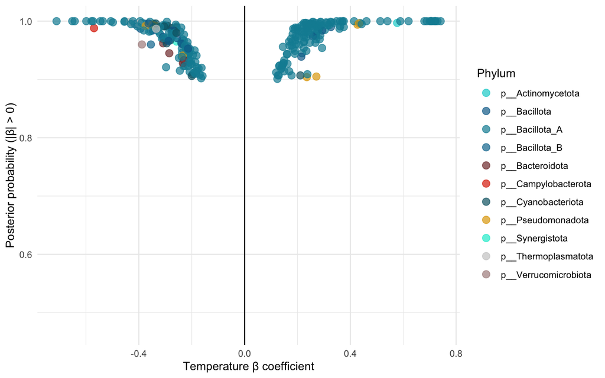

```r
# Extract beta estimate and support using helper functions
temp_estimate <- get_beta_estimate(fit_model_18, m, "temperature")
temp_support <- get_beta_support(fit_model_18, m, "temperature")

temp_beta <- inner_join(temp_estimate, temp_support, by = "genome") %>%
  left_join(genome_metadata, by = "genome")

temp_beta %>%
  mutate(significant = support >= support_threshold | support <= negsupport_threshold,
         support_plot = ifelse(mean < 0, 1 - support, support),
         phylum_sig = ifelse(significant & support_plot > 0.9, phylum, NA)) %>%
  ggplot(aes(x = mean, y = support_plot, colour = phylum_sig)) +
  geom_point(alpha = 0.7, size = 3) +
  scale_color_manual(values = phylum_colors, na.translate = FALSE) +
  geom_vline(xintercept = 0) +
  labs(x = "Temperature β coefficient",
       y = "Posterior probability (|β| > 0)",
       colour = "Phylum") +
  theme_minimal()
```

## Temperature credible intervals

**Note:** Calculate 10% and 90% credible intervals for temperature beta coefficients. Filter to genomes with credible non-zero effects (where the credible interval does not include zero) and create a forest plot showing beta estimates with error bars, ordered by effect size.

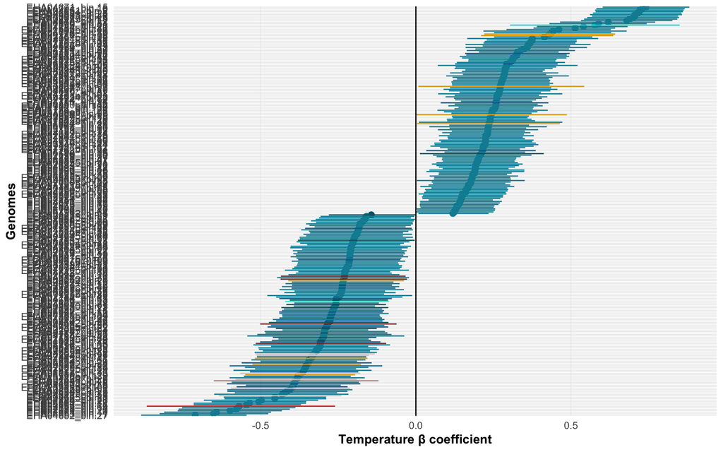

```r
# Credible intervals for temperature using helper function
temp_estimate <- get_beta_estimate(fit_model_18, m, "temperature")
temp_ci <- get_beta_ci(fit_model_18, m, "temperature") %>%
  right_join(temp_estimate, by = "genome") %>%
  left_join(genome_metadata, by = "genome")

temp_ci %>%
  filter(q10 > 0 | q90 < 0) %>%
  create_forest_plot(
    color_var = "phylum",
    color_values = phylum_colors,
    x_lab = "Temperature β coefficient",
    y_lab = "Genomes",
    show_legend = FALSE
  )
```

## 14.21 Temperature top genomes

**Note:** Identify the top 30 genomes with the strongest positive and top 30 with the strongest negative temperature associations (based on credible intervals). Create a focused forest plot with faceting by direction (positive/negative), showing only these top genomes with their credible intervals, providing a clear view of the most extreme temperature associations.

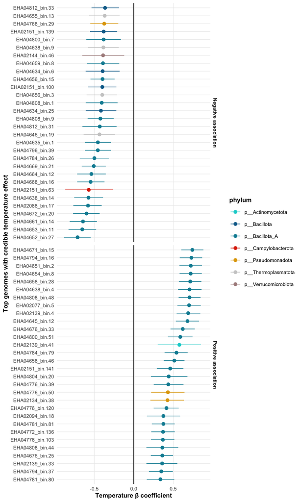

```r
# Reuse temp_ci from previous chunk if available, otherwise create it
if (!exists("temp_ci")) {
  temp_estimate <- get_beta_estimate(fit_model_18, m, "temperature")
  temp_ci <- get_beta_ci(fit_model_18, m, "temperature") %>%
    right_join(temp_estimate, by = "genome") %>%
    left_join(genome_metadata, by = "genome")
}

# Keep only genomes with credible non-zero temperature effect
temp_ci_sig <- temp_ci %>%
  filter(q10 > 0 | q90 < 0)

# 4. Take top 30 positive and top 30 negative genomes
N_top <- 30

temp_ci_top <- temp_ci_sig %>%
  dplyr::slice_max(order_by = mean, n = N_top, with_ties = FALSE) %>%
  dplyr::bind_rows(
    temp_ci_sig %>%
      dplyr::slice_min(order_by = mean, n = N_top, with_ties = FALSE)
  ) %>%
  dplyr::distinct(genome, .keep_all = TRUE) %>%
  dplyr::mutate(
    direction = ifelse(mean > 0, "Positive association", "Negative association"),
    genome    = forcats::fct_reorder(genome, mean)
  )

# 5. Plot credible intervals for these top genomes
temp_ci_top %>%
  create_forest_plot(
    color_var = "phylum",
    color_values = phylum_colors,
    x_lab = "Temperature β coefficient",
    y_lab = "Top genomes with credible temperature effect",
    base_size = 9,
    errorbar_width = 0,
    facet_var = "direction",
    show_legend = TRUE
  )
```

### 14.21.1 2) Temperature – phylum-level summary of β

## 14.22 Temperature phylum-level summary

**Note:** Aggregate temperature beta coefficients at the phylum level by calculating mean beta and credible intervals (10th and 90th percentiles) for each phylum. Create a forest plot showing phylum-level temperature associations to identify which phyla are generally positively or negatively associated with temperature.

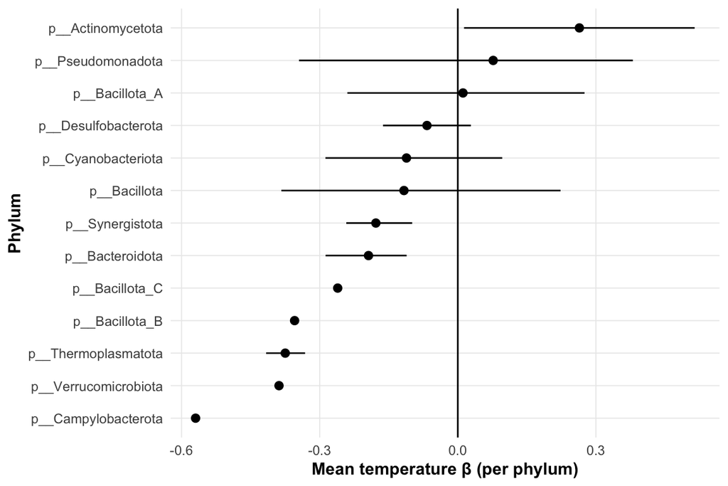

```r
# Reuse temp_ci from previous chunk if available, otherwise create it
if (!exists("temp_ci")) {
  temp_estimate <- get_beta_estimate(fit_model_18, m, "temperature")
  temp_ci <- get_beta_ci(fit_model_18, m, "temperature") %>%
    right_join(temp_estimate, by = "genome") %>%
    left_join(genome_metadata, by = "genome")
}

temp_phylum_ci <- aggregate_by_taxonomy(temp_ci, tax_level = "phylum")

temp_phylum_ci %>%
  create_forest_plot(
    x_var = "mean_beta",
    xmin_var = "q10",
    xmax_var = "q90",
    y_var = "phylum",
    x_lab = "Mean temperature β (per phylum)",
    y_lab = "Phylum",
    show_legend = FALSE
  )
```

## 14.23 Temperature functional differences

**Note:** Compare functional element abundances between genomes with positive versus negative temperature associations. For each GIFT element, calculate mean abundances in positive and negative groups, compute differences, and perform t-tests with Benjamini-Hochberg FDR correction to identify functional elements significantly enriched in one group.

```r
functional_differences_temperature <- calculate_functional_differences(
  elements_response,
  variable_name = "temperature"
)
```

## 14.24 Temperature functional differences volcano plot

**Note:** Create a volcano plot visualizing functional differences between positive and negative temperature-associated genomes. Plot mean difference (x-axis) versus negative log10 FDR (y-axis), colored by functional group. Highlight significant functional elements that exceed both fold-change and FDR thresholds, with labels for the most significant hits.

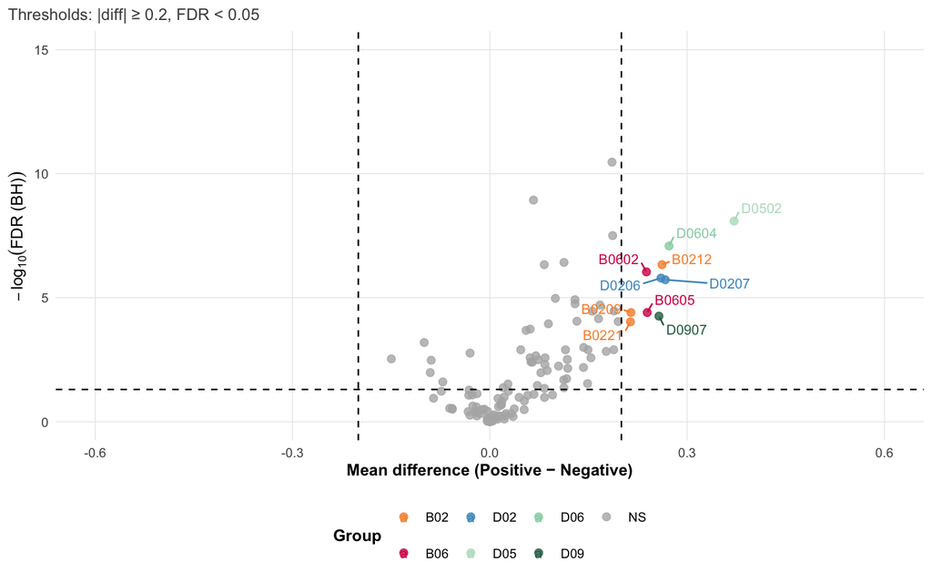

```r
create_volcano_plot(
  functional_differences_temperature,
  variable_label = "Temperature",
  gift_colors = gift_colors
)
```

## 14.25 Temperature functional group forest plot

**Note:** Aggregate temperature beta coefficients by functional group (GIFT 3-letter codes). For each functional group, calculate mean beta across all genomes carrying that function, along with credible intervals. Select top 15 positive and top 15 negative functional groups and create a forest plot showing functional-level temperature associations with appropriate color coding.

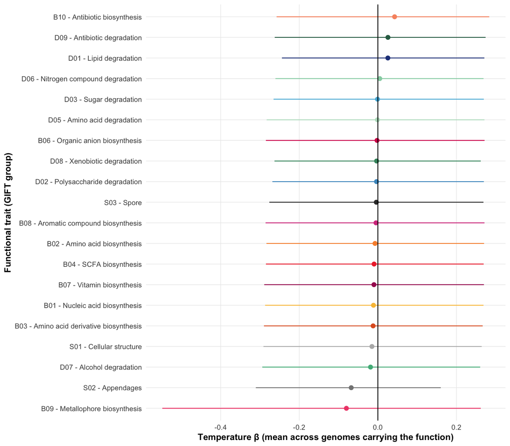

```r
# Extract temperature β and CI using helper function
temp_ci_all <- get_beta_complete(fit_model_18, m, "temperature")

# Aggregate by functional group using helper function
temp_func_top <- aggregate_by_function(
  temp_ci_all,
  elements_response,
  gift_colors,
  n_top = 15
)

# Create forest plot
func_cols_temp <- setNames(temp_func_top$color, temp_func_top$func_label)

temp_func_top %>%
  create_forest_plot(
    x_var = "mean_beta",
    xmin_var = "q10_fun",
    xmax_var = "q90_fun",
    y_var = "func_label",
    color_var = "func_label",
    color_values = func_cols_temp,
    x_lab = "Temperature β (mean across genomes carrying the function)",
    y_lab = "Functional trait (GIFT group)",
    base_size = 10,
    errorbar_width = 0,
    show_legend = FALSE
  )
```

## 14.26 Association with devil × temperature interaction

**Note:** Summarize genome-level associations with the devil × temperature interaction term. A positive interaction indicates that the devil effect strengthens with temperature; a negative interaction indicates the opposite.

```r
interaction_col <- "devil:temperature"
post_table[[interaction_col]] %>% table()
```

```
## .
## Positive  Neutral Negative
##      119      355      102
```

```r
interaction_phylum_perc <- post_table %>%
  rownames_to_column(var = "genome") %>%
  left_join(genome_metadata, by = "genome") %>%
  group_by(phylum) %>%
  summarise(
    positive = sum(.data[[interaction_col]] == "Positive"),
    percent_positive = mean(.data[[interaction_col]] == "Positive") * 100,
    negative = sum(.data[[interaction_col]] == "Negative"),
    percent_negative = mean(.data[[interaction_col]] == "Negative") * 100,
    .groups = "drop"
  )

interaction_phylum_perc %>%
  arrange(-percent_positive)
```

```
## # A tibble: 13 × 5
##    phylum               positive percent_positive negative percent_negative
##    <chr>                   <int>            <dbl>    <int>            <dbl>
##  1 p__Bacillota_B              1            100          0              0
##  2 p__Campylobacterota         1            100          0              0
##  3 p__Verrucomicrobiota        1            100          0              0
##  4 p__Bacteroidota             7             70          0              0
##  5 p__Desulfobacterota         1             50          0              0
##  6 p__Bacillota               14             48.3        4             13.8
##  7 p__Actinomycetota           1             33.3        1             33.3
##  8 p__Synergistota             2             33.3        0              0
##  9 p__Pseudomonadota           4             28.6        4             28.6
## 10 p__Cyanobacteriota          9             20          0              0
## 11 p__Bacillota_A             77             16.8       93             20.4
## 12 p__Thermoplasmatota         1             16.7        0              0
## 13 p__Bacillota_C              0              0          0              0
```

```r
interaction_phylum_perc %>%
  arrange(-percent_negative)
```

```
## # A tibble: 13 × 5
##    phylum               positive percent_positive negative percent_negative
##    <chr>                   <int>            <dbl>    <int>            <dbl>
##  1 p__Actinomycetota           1             33.3        1             33.3
##  2 p__Pseudomonadota           4             28.6        4             28.6
##  3 p__Bacillota_A             77             16.8       93             20.4
##  4 p__Bacillota               14             48.3        4             13.8
##  5 p__Bacillota_B              1            100          0              0
##  6 p__Bacillota_C              0              0          0              0
##  7 p__Bacteroidota             7             70          0              0
##  8 p__Campylobacterota         1            100          0              0
##  9 p__Cyanobacteriota          9             20          0              0
## 10 p__Desulfobacterota         1             50          0              0
## 11 p__Synergistota             2             33.3        0              0
## 12 p__Thermoplasmatota         1             16.7        0              0
## 13 p__Verrucomicrobiota        1            100          0              0
```

## 14.27 Devil × temperature interaction beta coefficients

**Note:** Extract posterior mean beta coefficients and support values for the devil × temperature interaction.

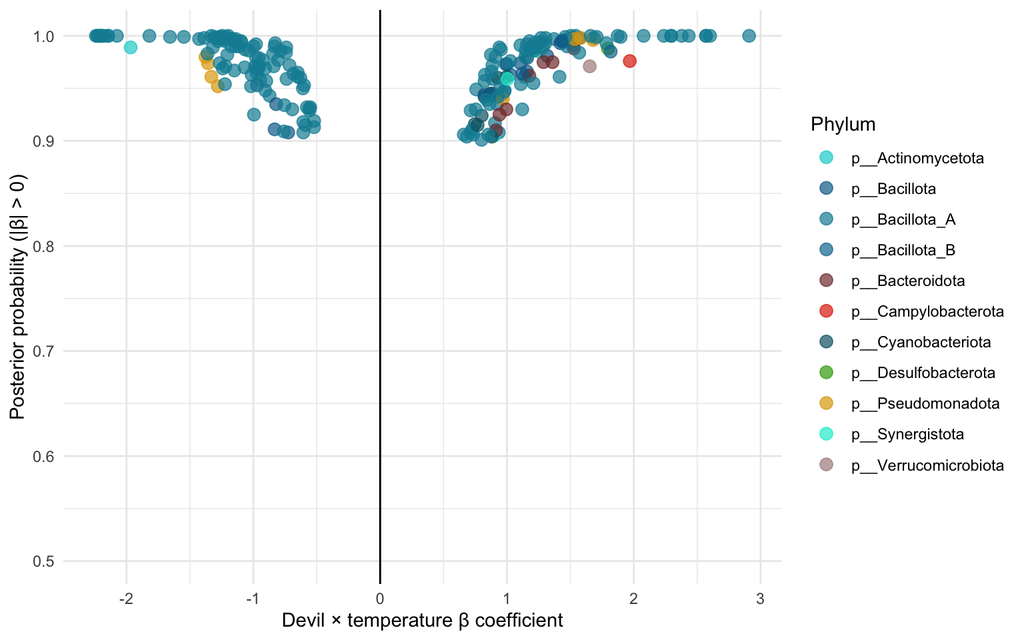

```r
interaction_estimate <- get_beta_estimate(fit_model_18, m, "devil:temperature")
interaction_support <- get_beta_support(fit_model_18, m, "devil:temperature")

interaction_beta <- inner_join(interaction_estimate, interaction_support, by = "genome") %>%
  left_join(genome_metadata, by = "genome")

interaction_beta %>%
  mutate(
    significant = support >= support_threshold | support <= negsupport_threshold,
    support_plot = ifelse(mean < 0, 1 - support, support),
    phylum_sig = ifelse(significant & support_plot > 0.9, phylum, NA)
  ) %>%
  ggplot(aes(x = mean, y = support_plot, colour = phylum_sig)) +
  geom_point(alpha = 0.7, size = 3) +
  scale_color_manual(values = phylum_colors, na.translate = FALSE) +
  geom_vline(xintercept = 0) +
  labs(
    x = "Devil × temperature β coefficient",
    y = "Posterior probability (|β| > 0)",
    colour = "Phylum"
  ) +
  theme_minimal()
```

## 14.28 Devil × temperature interaction credible intervals

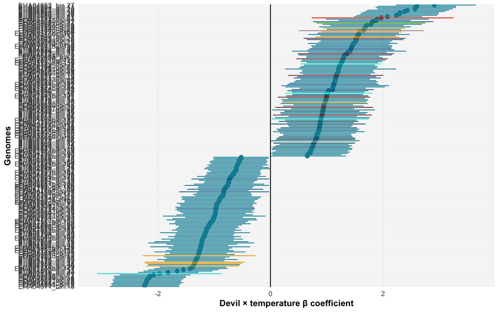

```r
interaction_ci <- get_beta_ci(fit_model_18, m, "devil:temperature") %>%
  right_join(interaction_estimate, by = "genome") %>%
  left_join(genome_metadata, by = "genome")

interaction_ci %>%
  filter(q10 > 0 | q90 < 0) %>%
  create_forest_plot(
    color_var = "phylum",
    color_values = phylum_colors,
    x_lab = "Devil × temperature β coefficient",
    y_lab = "Genomes",
    show_legend = FALSE
  )
```

## 14.29 Devil × temperature interaction top genomes

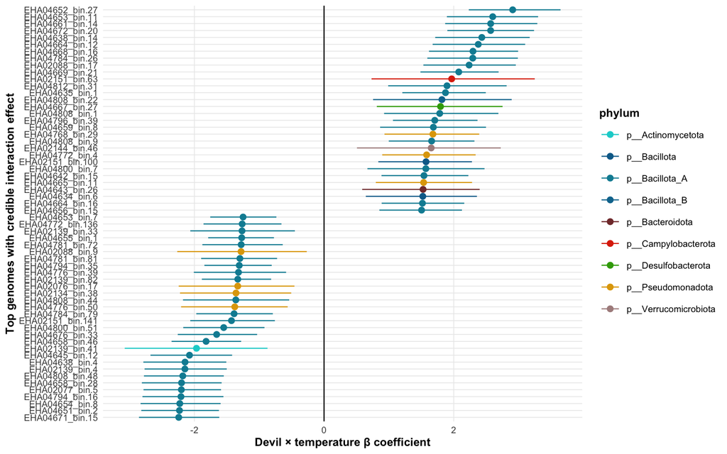

```r
interaction_ci_sig <- interaction_ci %>%
  filter(q10 > 0 | q90 < 0)

N_top <- 30

interaction_ci_top <- interaction_ci_sig %>%
  slice_max(order_by = mean, n = N_top, with_ties = FALSE) %>%
  bind_rows(
    interaction_ci_sig %>%
      slice_min(order_by = mean, n = N_top, with_ties = FALSE)
  ) %>%
  distinct(genome, .keep_all = TRUE)

interaction_ci_top %>%
  create_forest_plot(
    color_var = "phylum",
    color_values = phylum_colors,
    x_lab = "Devil × temperature β coefficient",
    y_lab = "Top genomes with credible interaction effect",
    base_size = 9,
    errorbar_width = 0,
    show_legend = TRUE
  )
```

## 14.30 Devil × temperature interaction phylum-level summary

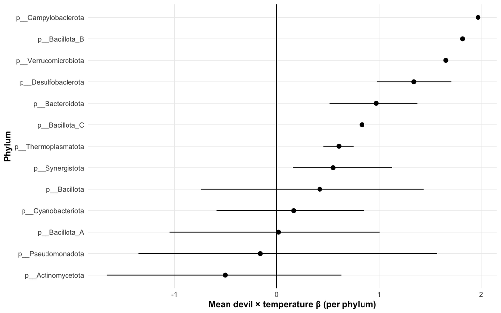

```r
interaction_phylum_ci <- aggregate_by_taxonomy(interaction_ci, tax_level = "phylum")

interaction_phylum_ci %>%
  create_forest_plot(
    x_var = "mean_beta",
    xmin_var = "q10",
    xmax_var = "q90",
    y_var = "phylum",
    x_lab = "Mean devil × temperature β (per phylum)",
    y_lab = "Phylum",
    show_legend = FALSE
  )
```

## 14.31 Devil × temperature interaction functional differences

```r
functional_differences_interaction <- calculate_functional_differences(
  elements_response,
  variable_name = "devil:temperature"
)
```

## 14.32 Devil × temperature interaction functional differences volcano plot

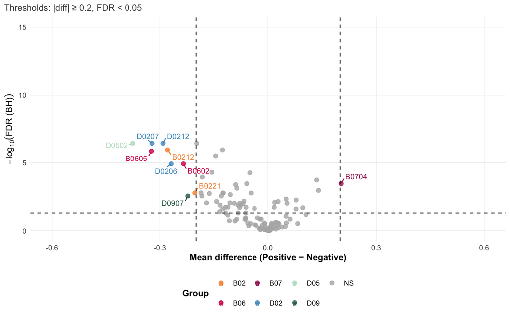

```r
create_volcano_plot(
  functional_differences_interaction,
  variable_label = "Devil × temperature",
  gift_colors = gift_colors
)
```

## 14.33 Devil × temperature interaction functional group forest plot

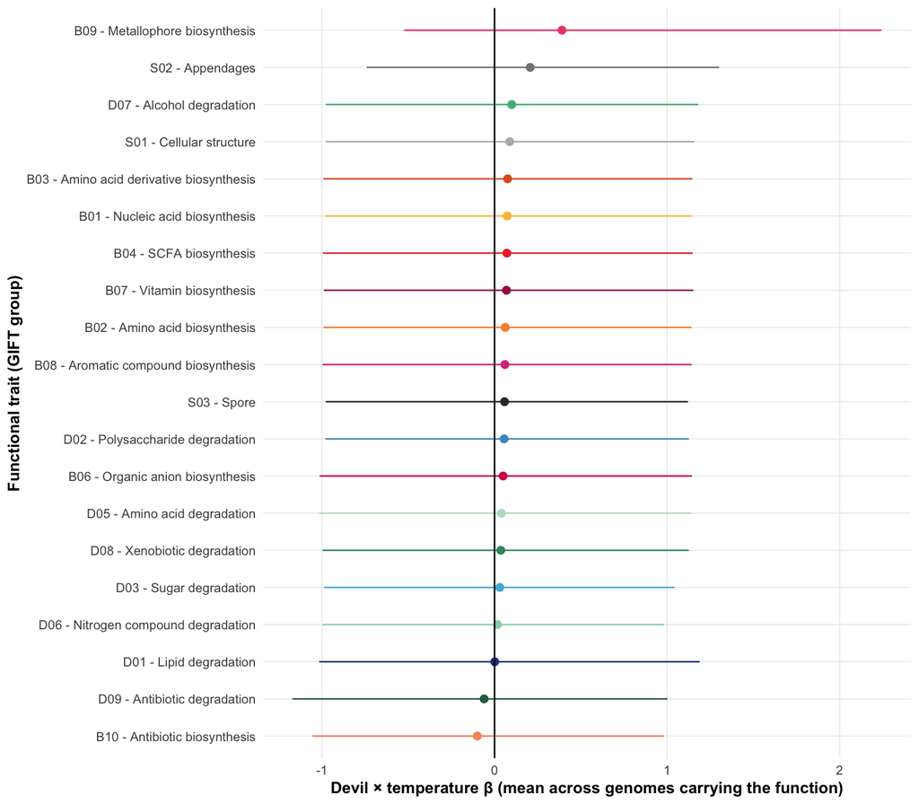

```r
interaction_ci_all <- get_beta_complete(fit_model_18, m, "devil:temperature")

interaction_func_top <- aggregate_by_function(
  interaction_ci_all,
  elements_response,
  gift_colors,
  n_top = 15
)

interaction_func_cols <- setNames(interaction_func_top$color, interaction_func_top$func_label)

interaction_func_top %>%
  create_forest_plot(
    x_var = "mean_beta",
    xmin_var = "q10_fun",
    xmax_var = "q90_fun",
    y_var = "func_label",
    color_var = "func_label",
    color_values = interaction_func_cols,
    x_lab = "Devil × temperature β (mean across genomes carrying the function)",
    y_lab = "Functional trait (GIFT group)",
    base_size = 10,
    errorbar_width = 0,
    show_legend = FALSE
  )
```

## 14.34 Association with diversity

**Note:** Summarize diversity associations across taxonomic levels. Count positive and negative associations with diversity and calculate percentages at phylum, order, family, and genus levels.

```r
post_table$diversity %>% table()
```

```
## .
## Positive  Neutral Negative
##      133      334      109
```

```r
diversity_phylum_perc <- post_table %>%
  rownames_to_column(var = "genome") %>%
  left_join(genome_metadata, by = "genome") %>%
  group_by(phylum) %>%
  summarise(positive = sum(diversity == "Positive"),
            percent_positive = mean(diversity == "Positive") * 100,
            negative = sum(diversity == "Negative"),
            percent_negative = mean(diversity == "Negative") * 100)

diversity_phylum_perc %>%
  arrange(-percent_positive)
```

```
## # A tibble: 13 × 5
##    phylum               positive percent_positive negative percent_negative
##    <chr>                   <int>            <dbl>    <int>            <dbl>
##  1 p__Bacillota_B              1            100          0              0
##  2 p__Thermoplasmatota         6            100          0              0
##  3 p__Bacillota               16             55.2        0              0
##  4 p__Bacillota_A            108             23.6       53             11.6
##  5 p__Synergistota             1             16.7        3             50
##  6 p__Bacteroidota             1             10          3             30
##  7 p__Actinomycetota           0              0          1             33.3
##  8 p__Bacillota_C              0              0          0              0
##  9 p__Campylobacterota         0              0          0              0
## 10 p__Cyanobacteriota          0              0         40             88.9
## 11 p__Desulfobacterota         0              0          0              0
## 12 p__Pseudomonadota           0              0          9             64.3
## 13 p__Verrucomicrobiota        0              0          0              0
```

```r
diversity_phylum_perc %>%
  arrange(-percent_negative)
```

```
## # A tibble: 13 × 5
##    phylum               positive percent_positive negative percent_negative
##    <chr>                   <int>            <dbl>    <int>            <dbl>
##  1 p__Cyanobacteriota          0              0         40             88.9
##  2 p__Pseudomonadota           0              0          9             64.3
##  3 p__Synergistota             1             16.7        3             50
##  4 p__Actinomycetota           0              0          1             33.3
##  5 p__Bacteroidota             1             10          3             30
##  6 p__Bacillota_A            108             23.6       53             11.6
##  7 p__Bacillota               16             55.2        0              0
##  8 p__Bacillota_B              1            100          0              0
##  9 p__Bacillota_C              0              0          0              0
## 10 p__Campylobacterota         0              0          0              0
## 11 p__Desulfobacterota         0              0          0              0
## 12 p__Thermoplasmatota         6            100          0              0
## 13 p__Verrucomicrobiota        0              0          0              0
```

```r
# Sub-phylum level

post_table %>%
  rownames_to_column(var = "genome") %>%
  left_join(genome_metadata, by = "genome") %>%
  filter(phylum=="p__Bacillota_A") %>%
  group_by(order) %>%
  summarise(positive = sum(diversity == "Positive"),
            percent_positive = mean(diversity == "Positive") * 100,
            negative = sum(diversity == "Negative"),
            percent_negative = mean(diversity == "Negative") * 100) %>%
  arrange(-percent_positive)
```

```
## # A tibble: 8 × 5
##   order                   positive percent_positive negative percent_negative
##   <chr>                      <int>            <dbl>    <int>            <dbl>
## 1 o__TANB77                     42             89.4        0              0
## 2 o__Christensenellales         29             35.8        0              0
## 3 o__Lachnospirales             34             18.5       24             13.0
## 4 o__Oscillospirales             3              2.4       28             22.4
## 5 o__Monoglobales                0              0          1             33.3
## 6 o__Peptostreptococcales        0              0          0              0
## 7 o__UBA1381                     0              0          0              0
## 8 o__UMGS1883                    0              0          0              0
```

```r
post_table %>%
  rownames_to_column(var = "genome") %>%
  left_join(genome_metadata, by = "genome") %>%
  filter(order=="o__TANB77") %>%
  group_by(family) %>%
  summarise(positive = sum(diversity == "Positive"),
            percent_positive = mean(diversity == "Positive") * 100,
            negative = sum(diversity == "Negative"),
            percent_negative = mean(diversity == "Negative") * 100) %>%
  arrange(-percent_positive)
```

```
## # A tibble: 2 × 5
##   family     positive percent_positive negative percent_negative
##   <chr>         <int>            <dbl>    <int>            <dbl>
## 1 f__CAG-465        6            100          0                0
## 2 f__CAG-508       36             87.8        0                0
```

```r
post_table %>%
  rownames_to_column(var = "genome") %>%
  left_join(genome_metadata, by = "genome") %>%
  filter(family=="f__CAG-508") %>%
  group_by(genus) %>%
  summarise(positive = sum(diversity == "Positive"),
            percent_positive = mean(diversity == "Positive") * 100,
            negative = sum(diversity == "Negative"),
            percent_negative = mean(diversity == "Negative") * 100) %>%
  arrange(-percent_positive)
```

```
## # A tibble: 9 × 5
##   genus          positive percent_positive negative percent_negative
##   <chr>             <int>            <dbl>    <int>            <dbl>
## 1 g__                   1            100          0                0
## 2 g__CAG-273            3            100          0                0
## 3 g__CAG-492            2            100          0                0
## 4 g__CAKPSH01           1            100          0                0
## 5 g__UMGS1994           4            100          0                0
## 6 g__CAG-269           11             91.7        0                0
## 7 g__Scatovivens       12             85.7        0                0
## 8 g__JAAWPK01           2             66.7        0                0
## 9 g__CAG-793            0              0          0                0
```

## 14.35 Diversity beta coefficients

**Note:** Extract posterior mean beta coefficients and support values for the diversity covariate.

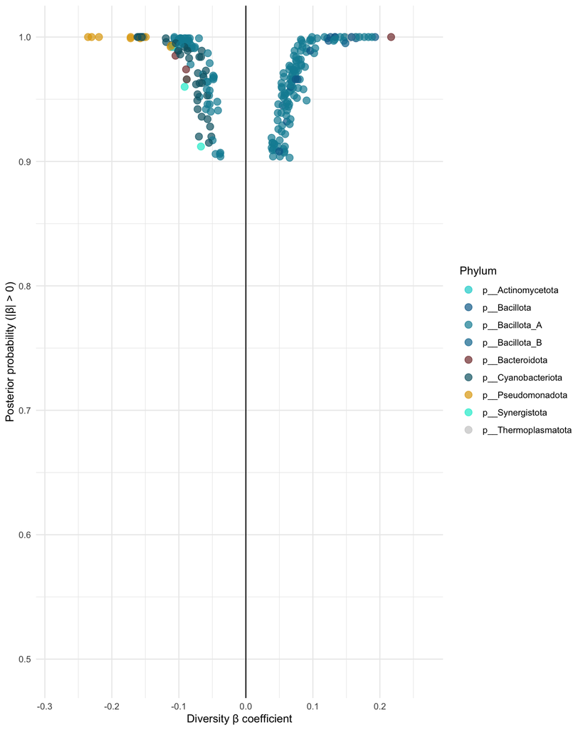

```r
# Extract beta estimate and support using helper functions
diversity_estimate <- get_beta_estimate(fit_model_18, m, "diversity")
diversity_support <- get_beta_support(fit_model_18, m, "diversity")

diversity_beta <- inner_join(diversity_estimate, diversity_support, by = "genome") %>%
  left_join(genome_metadata, by = "genome") %>%
  mutate(
    significant   = support >= support_threshold | support <= negsupport_threshold,
    support_plot  = ifelse(mean < 0, 1 - support, support),
    phylum_sig    = ifelse(significant & support_plot > 0.9, phylum, NA)
  )

diversity_xrange <- range(diversity_beta$mean, na.rm = TRUE)
diversity_xlim   <- diversity_xrange + c(-0.05, 0.05)

diversity_beta %>%
  ggplot(aes(x = mean, y = support_plot, colour = phylum_sig)) +
  geom_point(alpha = 0.7, size = 3) +
  scale_color_manual(values = phylum_colors, na.translate = FALSE) +
  geom_vline(xintercept = 0) +
  xlim(diversity_xlim) +
  labs(
    x = "Diversity β coefficient",
    y = "Posterior probability (|β| > 0)",
    colour = "Phylum"
  ) +
  theme_minimal()
```

```r
# Build complete CI dataset for later use
diversity_ci_all <- get_beta_complete(fit_model_18, m, "diversity")
```

## 14.36 Diversity credible intervals

**Note:** Calculate 10% and 90% credible intervals for diversity beta coefficients.

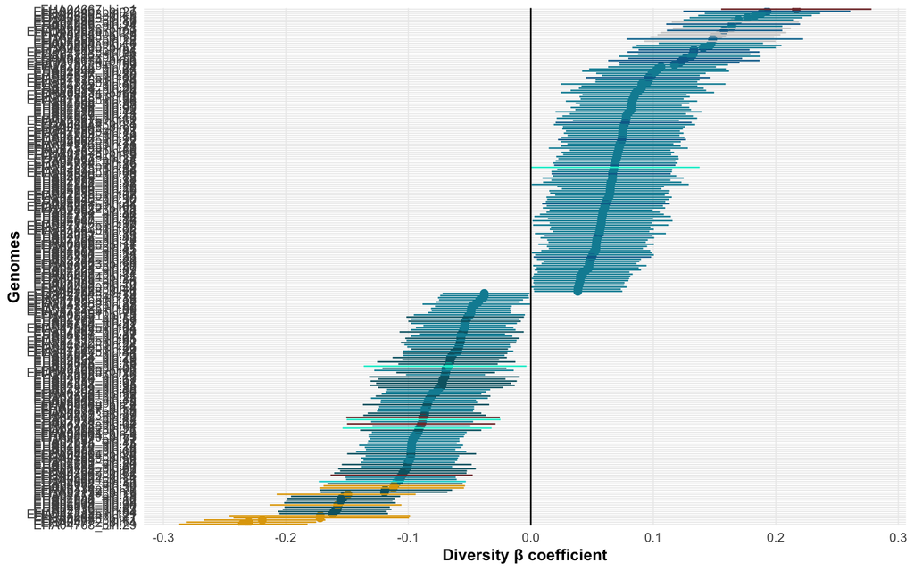

```r
# Credible intervals for diversity using helper function
diversity_estimate <- get_beta_estimate(fit_model_18, m, "diversity")
diversity_ci <- get_beta_ci(fit_model_18, m, "diversity") %>%
  right_join(diversity_estimate, by = "genome") %>%
  left_join(genome_metadata, by = "genome")

diversity_ci %>%
  filter(q10 > 0 | q90 < 0) %>%
  create_forest_plot(
    color_var = "phylum",
    color_values = phylum_colors,
    x_lab = "Diversity β coefficient",
    y_lab = "Genomes",
    show_legend = FALSE
  )
```

## 14.37 Diversity top genomes

**Note:** Identify the top 30 genomes with the strongest positive and top 30 with the strongest negative diversity associations.

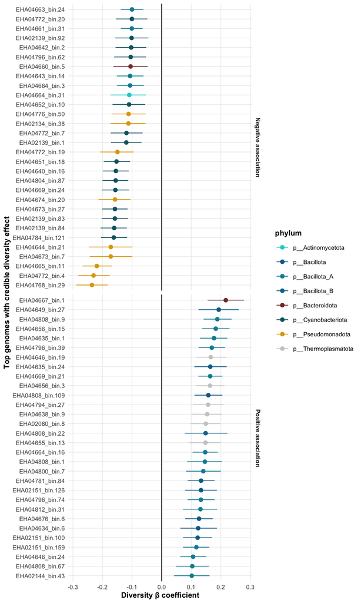

```r
# Reuse diversity_ci from previous chunk if available, otherwise create it
if (!exists("diversity_ci")) {
  diversity_estimate <- get_beta_estimate(fit_model_18, m, "diversity")
  diversity_ci <- get_beta_ci(fit_model_18, m, "diversity") %>%
    right_join(diversity_estimate, by = "genome") %>%
    left_join(genome_metadata, by = "genome")
}

diversity_ci_sig <- diversity_ci %>%
  filter(q10 > 0 | q90 < 0)

N_top <- 30

diversity_ci_top <- diversity_ci_sig %>%
  slice_max(order_by = mean, n = N_top, with_ties = FALSE) %>%
  bind_rows(
    diversity_ci_sig %>%
      slice_min(order_by = mean, n = N_top, with_ties = FALSE)
  ) %>%
  distinct(genome, .keep_all = TRUE) %>%
  mutate(
    direction = ifelse(mean > 0, "Positive association", "Negative association"),
    genome    = forcats::fct_reorder(genome, mean)
  )

diversity_ci_top %>%
  create_forest_plot(
    color_var = "phylum",
    color_values = phylum_colors,
    x_lab = "Diversity β coefficient",
    y_lab = "Top genomes with credible diversity effect",
    base_size = 9,
    errorbar_width = 0,
    facet_var = "direction",
    show_legend = TRUE
  )
```

## 14.38 Diversity phylum-level summary

**Note:** Aggregate diversity beta coefficients at the phylum level.

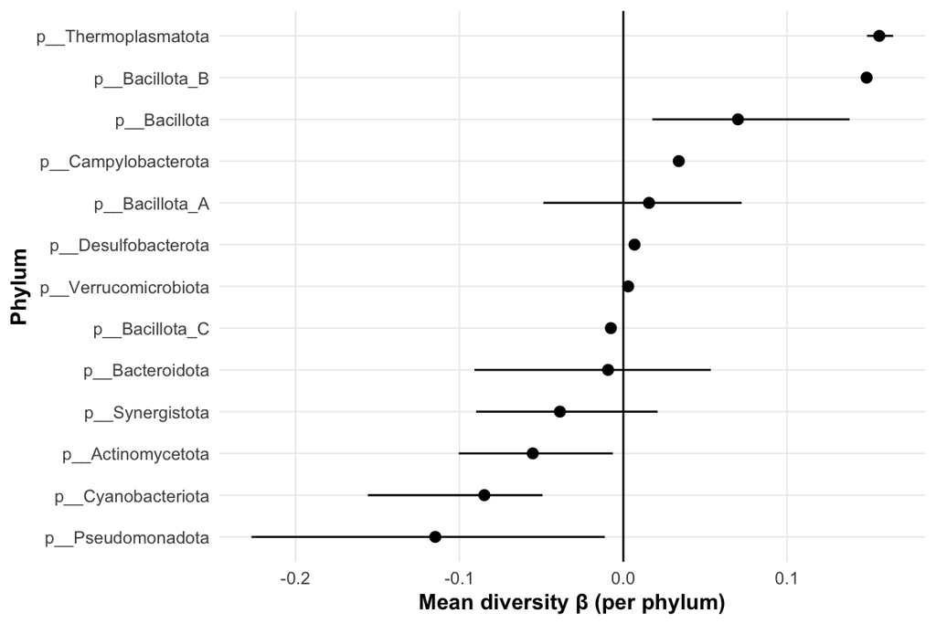

```r
# Reuse diversity_ci from previous chunk if available, otherwise create it
if (!exists("diversity_ci")) {
  diversity_estimate <- get_beta_estimate(fit_model_18, m, "diversity")
  diversity_ci <- get_beta_ci(fit_model_18, m, "diversity") %>%
    right_join(diversity_estimate, by = "genome") %>%
    left_join(genome_metadata, by = "genome")
}

diversity_phylum_ci <- aggregate_by_taxonomy(diversity_ci, tax_level = "phylum")

diversity_phylum_ci %>%
  create_forest_plot(
    x_var = "mean_beta",
    xmin_var = "q10",
    xmax_var = "q90",
    y_var = "phylum",
    x_lab = "Mean diversity β (per phylum)",
    y_lab = "Phylum",
    show_legend = FALSE
  )
```

## 14.39 Diversity functional differences

**Note:** Compare functional element abundances between genomes with positive versus negative diversity associations.

```r
functional_differences_diversity <- calculate_functional_differences(
  elements_response,
  variable_name = "diversity"
)
```

## 14.40 Diversity functional differences volcano plot

**Note:** Create a volcano plot visualizing functional differences between positive and negative diversity-associated genomes.

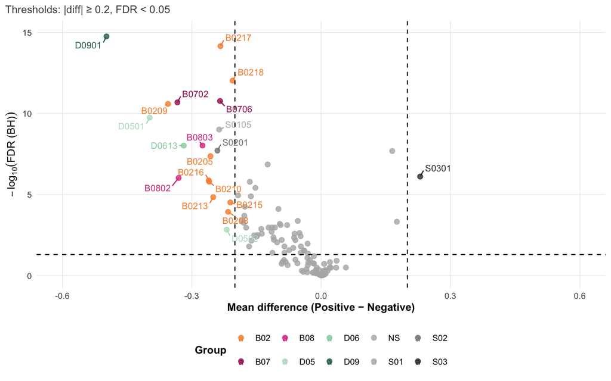

```r
create_volcano_plot(
  functional_differences_diversity,
  variable_label = "Diversity",
  gift_colors = gift_colors
)
```

## 14.41 Diversity functional group forest plot

**Note:** Aggregate diversity beta coefficients by functional group (GIFT 3-letter codes).

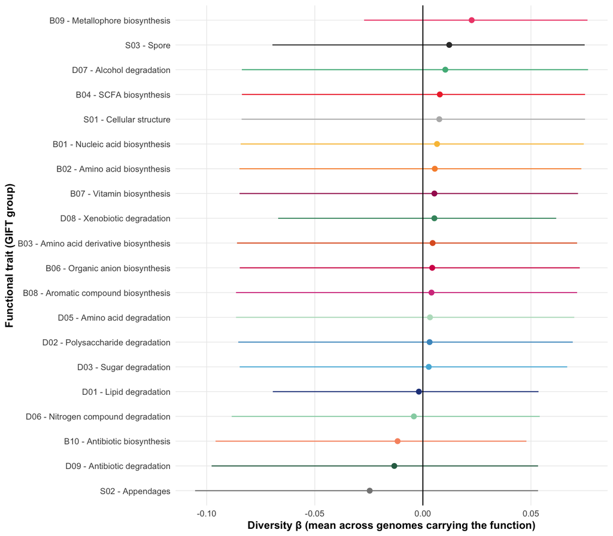

```r
diversity_func_top <- aggregate_by_function(
  diversity_ci_all,
  elements_response,
  gift_colors,
  n_top = 15
)

diversity_func_cols <- setNames(diversity_func_top$color, diversity_func_top$func_label)

diversity_func_top %>%
  create_forest_plot(
    x_var = "mean_beta",
    xmin_var = "q10_fun",
    xmax_var = "q90_fun",
    y_var = "func_label",
    color_var = "func_label",
    color_values = diversity_func_cols,
    x_lab = "Diversity β (mean across genomes carrying the function)",
    y_lab = "Functional trait (GIFT group)",
    base_size = 10,
    errorbar_width = 0,
    show_legend = FALSE
  )
```